Coding Essentials for Astronomers

# SciPy: Interpolation, Differentiation and Integration

## Introduction

In Lecture 15, you learned to compute precise planetary positions using SkyField. You calculated the Moon's position every 6 hours or every day, tracked its motion across the sky, and identified events like when it rises or reaches maximum altitude. These calculations gave you positions at specific discrete time points - like taking snapshots at regular intervals.

But astronomical analysis often requires answering questions that fall between these discrete snapshots. What if you need the Moon's position at exactly 3:17 AM when you only computed positions at midnight and 6 AM? What if you need to find the precise moment when the Moon is moving fastest? What if you want to know the total angular distance the Moon traveled over a week, not just its position at specific times?

These questions require three fundamental computational techniques that work with discrete data. **Interpolation** lets you estimate values between known points - it's actually the simplest form of "machine learning" where we learn patterns from data and make predictions at new points! **Differentiation** reveals rates of change, like the Moon's angular velocity or acceleration. **Integration** accumulates quantities over time, such as total distance traveled or time-averaged altitude. Think of it like having snapshots of a child growing up with photos every month. Interpolation estimates height at 2.5 months, differentiation reveals growth rate at any age, and integration calculates total growth over the year.

You could solve these problems by calling SkyField at every possible millisecond, but that would be extremely slow. (Interestingly, SkyField itself uses interpolation internally - it uses Chebyshev polynomials to interpolate JPL's ephemeris data, which is more accurate but computationally expensive. For our simpler tasks, we can use faster interpolation methods.) Or you could write your own numerical algorithms from scratch, but that's error-prone and time-consuming. Instead, **SciPy (Scientific Python)** provides efficient, battle-tested functions for these operations.

### What is SciPy?

SciPy is one of the core libraries in the scientific Python ecosystem. While NumPy provides fundamental array operations and basic mathematical functions, SciPy builds on top of NumPy to provide specialized algorithms for scientific computing. Think of NumPy as providing the basic tools (arrays, addition, multiplication), while SciPy provides the advanced power tools (interpolation, optimization, signal processing, statistics).

SciPy is organized into submodules, each focused on a specific domain:

- `scipy.interpolate` - Functions for interpolating between data points
- `scipy.integrate` - Numerical integration and solving differential equations
- `scipy.stats` - Statistical functions and distributions
- `scipy.signal` - Signal processing (filtering, peak finding, etc.)
- `scipy.optimize` - Optimization and root-finding algorithms
- `scipy.linalg` - Linear algebra routines (more complete than NumPy's)
- And many more...

In this lecture, we'll focus primarily on **`scipy.interpolate`** and **`scipy.integrate`**, which are particularly relevant for working with astronomical time-series data. These functions have been refined over decades by computational scientists and are used in research worldwide. They're fast (often implemented in C, C++, or Fortran), numerically stable, and well-documented. Rather than reinventing the wheel, we can leverage this mature ecosystem for our astronomical calculations.

In this lecture, you'll learn how to apply these mathematical techniques to astronomical data, particularly the ephemeris data you've been generating with SkyField. By the end, you'll be able to create fast lookup tables for celestial positions, analyze rates of change to find important events, and compute accumulated motion. These are all essential skills for observational astronomy and data analysis.

## Getting Started

Let's begin by importing the fundamental libraries we'll use throughout this lecture. We need NumPy for numerical arrays and mathematical operations, and matplotlib for creating visualizations. We'll import specific SciPy modules as we need them throughout the tutorial.

```python
# Import NumPy for numerical arrays and mathematical operations
import numpy as np

# Import Matplotlib for creating visualizations
import matplotlib.pyplot as plt
```

Configure matplotlib to create figures with consistent sizing and readable fonts throughout this notebook. The `rcParams` dictionary controls default settings for all plots we create:

```python
# Configure default figure size for all plots: 12 inches wide, 8 inches tall
plt.rcParams['figure.figsize'] = (12, 8)

# Set default font size to 12 points for better readability
plt.rcParams['font.size'] = 12
```

Now let's set up SkyField to generate the planetary ephemeris data we'll work with. If you completed Lecture 15, this setup will look familiar. We'll load the **DE440s ephemeris file**, which is JPL's (Jet Propulsion Laboratory) high-precision planetary ephemeris in compressed form. It contains positions of planets, the Sun, and the Moon, and it's accurate enough for most astronomical calculations while being small enough to download quickly.

The `load()` function automatically downloads the file if you don't have it, or uses a cached version if you've already downloaded it. This makes it very convenient for repeated use:

```python
# Import SkyField tools: load() for downloading data, wgs84 for Earth coordinates
from skyfield.api import load, wgs84

# Load the DE440s ephemeris (JPL's high-precision planetary positions)
# This automatically downloads the file if not cached locally
eph = load('de440s.bsp')
print("Ephemeris loaded successfully")
```

```
[                                 ]   0% de440s.bsp
```

```
[########                         ]  25% de440s.bsp
```

```
[#######################          ]  70% de440s.bsp
```

```
[#################################] 100% de440s.bsp
```

```
Ephemeris loaded successfully
```

Extract the Earth and Moon objects from the ephemeris. The ephemeris file contains data for many solar system bodies, and we can access them by name using dictionary-style indexing. We'll use Earth as our observation point (since we're observers on Earth's surface) and track the Moon's position as it moves across our sky.

The Moon is an excellent target for this tutorial because it moves quickly enough (about 0.5 degrees per hour, or roughly its own diameter each hour) that we can see significant changes over just a few days. This makes the effects of interpolation and differentiation easy to observe and understand:

```python
# Extract Earth and Moon objects from the ephemeris using dictionary-style access
earth = eph['earth']  # Earth's center (our observation point)
moon = eph['moon']    # The Moon (our target object)
```

Create a timescale object for time conversions. SkyField uses this to handle the complexities of astronomical time systems. The timescale object handles all conversions between these systems automatically. We also define our observer location using `wgs84.latlon()`, which specifies latitude, longitude, and elevation. The WGS84 system is the standard geodetic system used by GPS and defines how we specify locations on Earth's surface.

We'll observe from Columbus, Ohio, at latitude 39.9612°N, longitude 83.0003°W, and elevation 260 meters. The notation `earth + wgs84.latlon(...)` creates a topocentric (Earth-surface) observer by combining Earth's center with a specific location on its surface:

```python
# Create a timescale object for handling time conversions (UTC, UT1, TT, etc.)
ts = load.timescale()

# Define observer location: Columbus, Ohio
# Latitude: 39.9612°N (positive = North), Longitude: 83.0003°W (negative = West)
# Elevation: 260 meters above sea level
# The '+' operator combines Earth's center with a specific surface location
columbus = earth + wgs84.latlon(39.9612, -83.0003, elevation_m=260)
```

### Generating Sparse Ephemeris Data

Now we'll compute the Moon's position at sparse time intervals. This simulates a realistic scenario where computing exact positions is expensive, either computationally or observationally, so we can't calculate them at every instant. Imagine an observer who can only measure the Moon's position every 6 hours due to equipment limitations, or a simulation that's too slow to run continuously.

Our goal is to create observations every 6 hours over a 7-day period. Why these specific choices?

**6-hour sampling**: This gives us 4 points per day, which is sparse enough that we'll genuinely need interpolation for intermediate times, but dense enough to capture the Moon's orbital motion without missing major features. The Moon completes one orbit around Earth in about 27.3 days, so over 7 days it moves through roughly a quarter of its orbit.

**7-day period**: This is long enough to see multiple Moon transits (when it crosses the meridian and reaches maximum altitude), observe both rising and setting events, and see significant changes in position. It's also a convenient timescale for human observation - about a week of data.

This sparse sampling is our starting point. Later, we'll use interpolation to estimate positions at arbitrary intermediate times without having to call the expensive SkyField calculations:

```python
# Generate sparse time points: every 6 hours for 7 days starting Jan 1, 2024
# np.arange(start, stop, step) creates array: 0, 6, 12, 18, 24, 30, 36, ... up to 162
# Total: 7 days × 24 hours/day = 168 hours, sampled every 6 hours = 28 points
hours = np.arange(0, 7*24, 6)

# Create SkyField time objects from year, month, day, and hour arrays
times_sparse = ts.utc(2024, 1, 1, hours)  # SkyField broadcasts: creates Time object for each hour

# Get Julian Date (JD) for easier numerical manipulation as our x-axis for interpolation
# We use TT (Terrestrial Time) as a uniform time coordinate
# SkyField handles time scale conversions internally when computing ephemerides
sparse_jd = times_sparse.tt

# Display the time range we've created
print(f"Generated {len(times_sparse)} time points")
print(f"From {times_sparse[0].utc_strftime('%Y-%m-%d %H:%M')} to {times_sparse[-1].utc_strftime('%Y-%m-%d %H:%M')}")
```

```
Generated 28 time points
From 2024-01-01 00:00 to 2024-01-07 18:00
```

**Understanding SkyField time creation:** The `ts.utc(2024, 1, 1, hours)` call demonstrates SkyField's convenient broadcasting. When you pass an array for the hours parameter, it automatically creates a Time object for each hour value. This is similar to NumPy's broadcasting - it's like calling `ts.utc(2024, 1, 1, 0)`, `ts.utc(2024, 1, 1, 6)`, etc., but much more efficient. Alternatively, you could use `ts.linspace(start_time, end_time, num_points)` to create evenly-spaced times, which is even more convenient for some applications.

Now compute the Moon's altitude and azimuth at these sparse times as seen from Columbus. The method returns three values: altitude, azimuth, and distance. We extract just altitude and azimuth and convert them to degrees for easier interpretation:

```python
# Compute Moon's position at each sparse time point as seen from Columbus
# columbus.at(times) = position at those times
# .observe(moon) = direction to the Moon (corrected for light travel time)
# .apparent() = apply atmospheric refraction and aberration corrections
moon_obs = columbus.at(times_sparse).observe(moon).apparent()

# Extract altitude (angle above horizon) and azimuth (compass direction)
# altaz() returns: altitude, azimuth, distance
alt, az, _ = moon_obs.altaz()

# Convert from SkyField angle objects to simple NumPy arrays in degrees
sparse_alt = alt.degrees  # Altitude: -90° (straight down) to +90° (straight up)
sparse_az = az.degrees    # Azimuth: 0° (North), 90° (East), 180° (South), 270° (West)

# Display summary of the data we've computed
print(f"Sparse data: {len(sparse_alt)} points over {(sparse_jd[-1] - sparse_jd[0]):.1f} days")
```

```
Sparse data: 28 points over 6.8 days
```

## Interpolation - Filling the Gaps

Interpolation is the process of estimating values between known data points. Think of it like this: if you know the temperature was 60°F at 9 AM and 75°F at noon, interpolation helps you estimate it was probably around 68°F at 10:30 AM. The fundamental assumption is that the quantity you're measuring changes smoothly between your measurement times. For astronomical objects following Newtonian dynamics, this is an excellent assumption over short time scales. SciPy provides several interpolation methods, each with different tradeoffs between simplicity, smoothness, and computational cost.

Let's start by importing SciPy's interpolation tools:

```python
# Import SciPy's interpolation module for creating interpolation functions
from scipy import interpolate
```

### Linear Interpolation: Connecting the Dots

Linear interpolation is the simplest method. It draws straight lines between your data points using the formula

$$y(x) = y_i + \frac{y_{i+1} - y_i}{x_{i+1} - x_i}(x - x_i),$$ which is just the equation of a line passing through the points $(x_i, y_i)$ and $(x_{i+1}, y_{i+1})$. While not as sophisticated as cubic splines, linear interpolation is fast, easy to understand, guaranteed to stay between your data values (no overshoot), and useful for quick estimates. We create interpolation functions using `interpolate.interp1d(x, y, kind='linear')`, which takes our sparse time and position data and returns a function object that can estimate positions at any time between our measurements.

```python
# Create linear interpolation functions for altitude and azimuth
# interp1d(x, y, kind='linear') takes x and y data and returns a function
# that estimates y for any x between the data points using straight lines
alt_interp_linear = interpolate.interp1d(sparse_jd, sparse_alt, kind='linear')
az_interp_linear = interpolate.interp1d(sparse_jd, sparse_az, kind='linear')
```

Now create a very dense time grid to truly showcase the interpolation quality. We'll use 30-second spacing (0.5/1440 days), which gives us extremely fine resolution. This dense grid will clearly reveal the differences between linear and cubic interpolation methods. With roughly 20,000 points over the week, we'll see smooth curves that accurately represent the Moon's continuous motion.

```python
# Create a very dense time grid with 30-second spacing
# 0.5/1440 days = 0.5 minutes = 30 seconds
# (1 day = 1440 minutes, so 1 minute = 1/1440 days)
dense_jd = np.arange(sparse_jd[0], sparse_jd[-1], 0.5/1440)
print(f"Created {len(dense_jd)} dense time points (30-second spacing)")
print(f"That's {len(dense_jd)/len(sparse_jd):.0f}× denser than sparse sampling")
```

```
Created 19440 dense time points (30-second spacing)
That's 694× denser than sparse sampling
```

Apply the linear interpolation functions to our dense grid. The syntax is beautifully simple - just call the interpolator like a regular function. This evaluates the interpolator at each time in our dense grid, giving us estimated positions every 30 seconds:

```python
# Evaluate the linear interpolation functions at all dense time points
# This gives us estimated altitude and azimuth every 30 seconds
dense_alt_linear = alt_interp_linear(dense_jd)
dense_az_linear = az_interp_linear(dense_jd)
```

Visualize the linear interpolation. We plot the interpolated curve as a smooth line and overlay our original sparse data points as red circles. This clearly shows how the interpolation function "fills in the gaps" between measurements. Look carefully at the interpolated curve - you should be able to see straight line segments between each pair of data points.

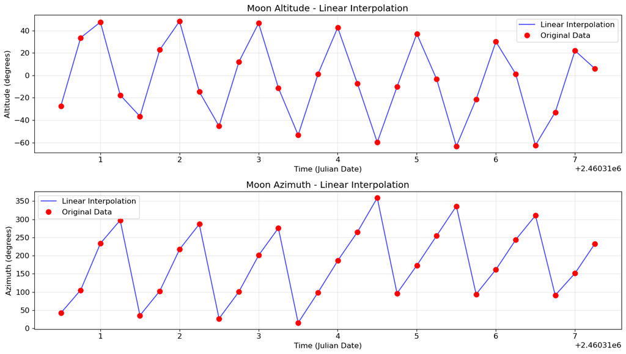

```python
# Create a two-panel figure to visualize linear interpolation for both altitude and azimuth
fig, (ax1, ax2) = plt.subplots(2, 1, figsize=(14, 8))

# Top panel: Altitude interpolation
# Plot the dense interpolated curve (blue line) with original sparse data (red circles)
ax1.plot(dense_jd, dense_alt_linear, 'b-', linewidth=1.5, label='Linear Interpolation', alpha=0.7)
ax1.plot(sparse_jd, sparse_alt, 'ro', markersize=8, label='Original Data')
ax1.set_xlabel('Time (Julian Date)')
ax1.set_ylabel('Altitude (degrees)')
ax1.set_title('Moon Altitude - Linear Interpolation')
ax1.grid(True, alpha=0.3)
ax1.legend()

# Bottom panel: Azimuth interpolation
ax2.plot(dense_jd, dense_az_linear, 'b-', linewidth=1.5, label='Linear Interpolation', alpha=0.7)
ax2.plot(sparse_jd, sparse_az, 'ro', markersize=8, label='Original Data')
ax2.set_xlabel('Time (Julian Date)')
ax2.set_ylabel('Azimuth (degrees)')
ax2.set_title('Moon Azimuth - Linear Interpolation')
ax2.grid(True, alpha=0.3)
ax2.legend()

plt.tight_layout()
plt.show()
```

Notice the straight-line segments between data points. While this creates a continuous path with no gaps, it still has sharp corners at each data point where the slope changes abruptly. For more realistic interpolation, we need cubic splines.

### Cubic Spline Interpolation: Smooth Curves

Cubic spline interpolation creates smooth, flowing curves instead of straight line segments. It fits piecewise cubic polynomials between points, where each segment has the form:

$$S_i(x) = a_i(x - x_i)^3 + b_i(x - x_i)^2 + c_i(x - x_i) + d_i$$

for $x \in [x_i, x_{i+1}]$. The key requirement is smoothness: the spline must satisfy continuity conditions at each data point (called knots):

- $S_i(x_{i+1}) = S_{i+1}(x_{i+1})$ (function continuity)
- $S_i'(x_{i+1}) = S_{i+1}'(x_{i+1})$ (first derivative continuity - no kinks)
- $S_i''(x_{i+1}) = S_{i+1}''(x_{i+1})$ (second derivative continuity - no sudden curvature changes)

These conditions create a system of equations that determines all the coefficients $a_i, b_i, c_i, d_i$. The mathematics is elegant but complex - fortunately SciPy handles it all for us.

Why cubic polynomials specifically? Lower-degree polynomials (linear, quadratic) don't provide enough flexibility for smooth curves, while higher-degree polynomials can create unwanted oscillations (Runge's phenomenon). Cubic is the sweet spot - enough flexibility for smooth curves without pathological behavior. We create cubic spline interpolators exactly the same way as linear, just changing `kind='cubic'`:

```python
# Create cubic spline interpolation functions for altitude and azimuth
# kind='cubic' fits smooth cubic polynomials between points
# This creates curves with continuous first and second derivatives (no kinks or sharp corners)
alt_interp_cubic = interpolate.interp1d(sparse_jd, sparse_alt, kind='cubic')
az_interp_cubic = interpolate.interp1d(sparse_jd, sparse_az, kind='cubic')
```

Evaluate the cubic spline interpolators on the same dense grid. This gives us smooth position estimates every 30 seconds using curves instead of straight lines:

```python
# Evaluate cubic spline interpolators on the same dense time grid
# This gives us smooth altitude and azimuth estimates every 30 seconds
dense_alt_cubic = alt_interp_cubic(dense_jd)
dense_az_cubic = az_interp_cubic(dense_jd)
```

Let's compare linear and cubic interpolation side by side for altitude. Notice how the cubic spline (green) creates smooth curves through the points while the linear interpolation (blue) has visible corners:

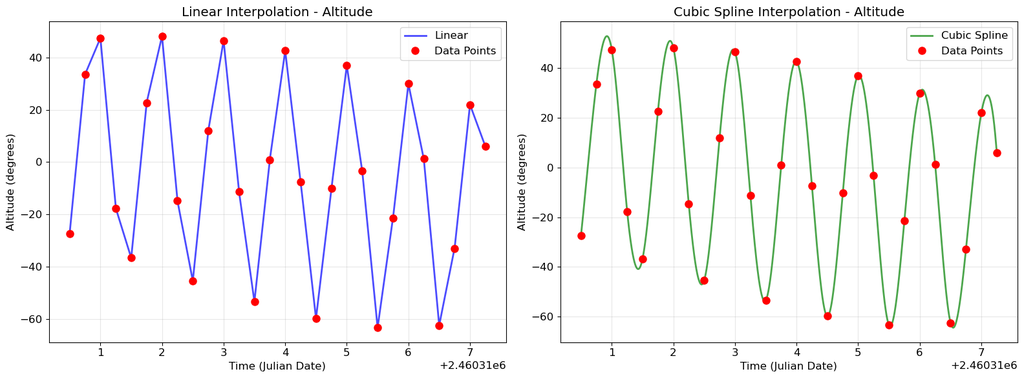

```python
# Create side-by-side comparison of linear vs cubic spline interpolation for altitude
fig, (ax1, ax2) = plt.subplots(1, 2, figsize=(16, 6))

# Left panel: Linear interpolation (blue)
# Shows straight line segments between data points
ax1.plot(dense_jd, dense_alt_linear, 'b-', linewidth=2, label='Linear', alpha=0.7)
ax1.plot(sparse_jd, sparse_alt, 'ro', markersize=8, label='Data Points')
ax1.set_xlabel('Time (Julian Date)')
ax1.set_ylabel('Altitude (degrees)')
ax1.set_title('Linear Interpolation - Altitude')
ax1.grid(True, alpha=0.3)
ax1.legend()

# Right panel: Cubic spline interpolation (green)
# Shows smooth curves through data points
ax2.plot(dense_jd, dense_alt_cubic, 'g-', linewidth=2, label='Cubic Spline', alpha=0.7)
ax2.plot(sparse_jd, sparse_alt, 'ro', markersize=8, label='Data Points')
ax2.set_xlabel('Time (Julian Date)')
ax2.set_ylabel('Altitude (degrees)')
ax2.set_title('Cubic Spline Interpolation - Altitude')
ax2.grid(True, alpha=0.3)
ax2.legend()

plt.tight_layout()
plt.show()
```

Now compare azimuth interpolation:

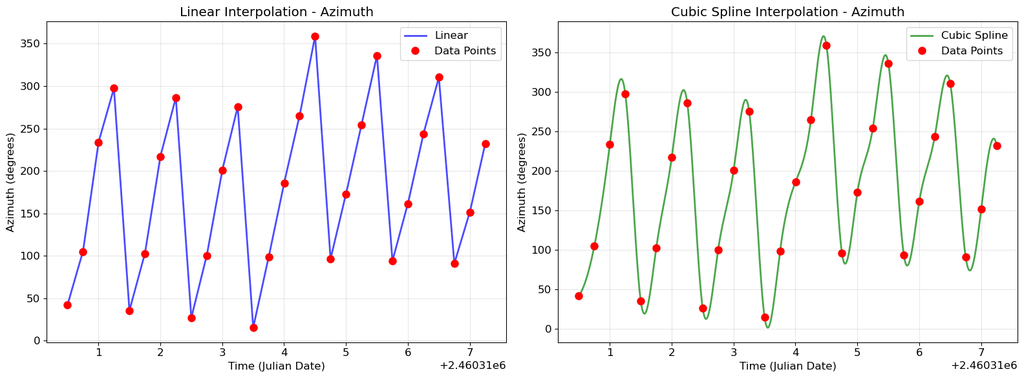

```python
# Create side-by-side comparison of linear vs cubic spline interpolation for azimuth
fig, (ax1, ax2) = plt.subplots(1, 2, figsize=(16, 6))

# Left panel: Linear interpolation (blue)
ax1.plot(dense_jd, dense_az_linear, 'b-', linewidth=2, label='Linear', alpha=0.7)
ax1.plot(sparse_jd, sparse_az, 'ro', markersize=8, label='Data Points')
ax1.set_xlabel('Time (Julian Date)')
ax1.set_ylabel('Azimuth (degrees)')
ax1.set_title('Linear Interpolation - Azimuth')
ax1.grid(True, alpha=0.3)
ax1.legend()

# Right panel: Cubic spline interpolation (green)
ax2.plot(dense_jd, dense_az_cubic, 'g-', linewidth=2, label='Cubic Spline', alpha=0.7)
ax2.plot(sparse_jd, sparse_az, 'ro', markersize=8, label='Data Points')
ax2.set_xlabel('Time (Julian Date)')
ax2.set_ylabel('Azimuth (degrees)')
ax2.set_title('Cubic Spline Interpolation - Azimuth')
ax2.grid(True, alpha=0.3)
ax2.legend()

plt.tight_layout()
plt.show()
```

The plots reveal that cubic spline creates much smoother curves than linear interpolation. Look closely at how the green cubic spline curves flow smoothly through each red data point, while the blue linear interpolation has visible "kinks" or corners at each point. For astronomical objects following smooth trajectories governed by continuous forces, cubic splines better represent physical reality.

### Validation: How Accurate is Our Interpolation?

So far, we've created beautiful interpolated curves, but are they accurate? Do they actually match the Moon's true position at intermediate times, or are we just drawing pretty curves through our data points? To find out, we'll use SkyField to compute the Moon's true position at times between our sparse measurements, then compare those exact values to our interpolated predictions. This validation process is crucial - it tells us how much error we introduce by interpolating instead of computing exact positions.

The validation strategy is simple but powerful: create a dense grid of test times (every 1 hour instead of our sparse 6-hour spacing), compute the exact Moon position at each test time using SkyField, get our interpolated predictions at those same times, and calculate the differences. These differences quantify our interpolation error.

First, create test times at 1-hour intervals. These fall "in between" our 6-hour sparse measurements:

```python
# Create a dense array of test times at 1-hour intervals over 7 days (168 hours total)
# These are different from our sparse 6-hour training data, so they test interpolation accuracy
test_hours = np.arange(0, 7*24, 1)

# Convert hours since start to (day, hour-within-day) format for SkyField
test_days = test_hours // 24  # Integer division: 0-23 hrs → day 0, 24-47 hrs → day 1, etc.
test_hours_in_day = test_hours % 24  # Modulo: hour within the day (0-23)

# Build date components: all times are in January 2024, starting from day 1
test_years = np.full_like(test_days, 2024)  # All 2024
test_months = np.full_like(test_days, 1)    # All January
test_days_offset = 1 + test_days  # Days 1-7 of January (add 1 to start from Jan 1, not Jan 0)

# Create SkyField time objects from the date/time components
times_test = ts.utc(test_years, test_months, test_days_offset, test_hours_in_day)

# Extract Julian dates for use with our interpolation functions
test_jd = times_test.tt
print(f"Created {len(test_jd)} test points for validation")
```

```
Created 168 test points for validation
```

Now compute the true Moon positions at these test times using SkyField. These are our "ground truth" values. We filter to only include times within our interpolation range (using `valid_mask`) to avoid extrapolation - interpolation functions are designed to work *between* known data points, and attempting to predict values *outside* this range (extrapolation) can produce wildly inaccurate results. By limiting to our valid range, we ensure we're only testing the interpolation where it's meant to work:

```python
# Filter test points to only those within our interpolation range
# Interpolation is valid only between min and max of training data; extrapolation is unreliable
valid_mask = (test_jd >= sparse_jd.min()) & (test_jd <= sparse_jd.max())
test_jd_valid = test_jd[valid_mask]  # Julian dates within valid range
times_test_valid = times_test[valid_mask]  # SkyField time objects within valid range

# Compute the TRUE Moon positions at test times using SkyField
# These are our ground truth values for validation
moon_test = columbus.at(times_test_valid).observe(moon).apparent()
true_alt, true_az, _ = moon_test.altaz()

# Convert to degrees for comparison with our interpolated values
true_alt = true_alt.degrees
true_az = true_az.degrees
```

Get the interpolated predictions at the same test times:

```python
# Get interpolated predictions at the same test times
# Using our cubic spline interpolators to estimate altitude and azimuth
interp_alt_at_test = alt_interp_cubic(test_jd_valid)
interp_az_at_test = az_interp_cubic(test_jd_valid)
```

Calculate the interpolation errors and display statistics:

```python
# Calculate interpolation errors by comparing predictions to ground truth
alt_errors = interp_alt_at_test - true_alt  # Positive = overestimate, negative = underestimate
az_errors = interp_az_at_test - true_az

# Display error statistics for altitude
print(f"Altitude interpolation errors:")
print(f"  Mean absolute error: {np.mean(np.abs(alt_errors)):.4f}°")  # Average magnitude of error
print(f"  Maximum error: {np.max(np.abs(alt_errors)):.4f}°")  # Worst case error
print(f"  RMS error: {np.sqrt(np.mean(alt_errors**2)):.4f}°")  # Root mean square (penalizes large errors)

# Display error statistics for azimuth
print(f"\nAzimuth interpolation errors:")
print(f"  Mean absolute error: {np.mean(np.abs(az_errors)):.4f}°")
print(f"  Maximum error: {np.max(np.abs(az_errors)):.4f}°")
print(f"  RMS error: {np.sqrt(np.mean(az_errors**2)):.4f}°")

# Provide context for interpreting the errors
print(f"\nFor reference, the Moon's apparent diameter is about 0.5°")
```

```
Altitude interpolation errors:
  Mean absolute error: 1.4658°
  Maximum error: 7.5066°
  RMS error: 2.0860°

Azimuth interpolation errors:
  Mean absolute error: 39.5931°
  Maximum error: 303.8580°
  RMS error: 74.6194°

For reference, the Moon's apparent diameter is about 0.5°
```

Visualize the interpolation errors over time:

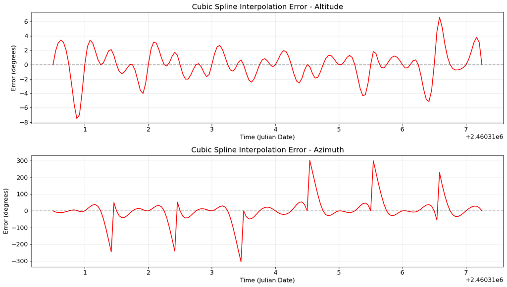

```python
# Visualize how interpolation errors vary over time
fig, (ax1, ax2) = plt.subplots(2, 1, figsize=(14, 8))

# Top panel: Altitude errors over time
ax1.plot(test_jd_valid, alt_errors, 'r-', linewidth=1.5)
ax1.axhline(y=0, color='k', linestyle='--', alpha=0.3)  # Zero error line
ax1.set_xlabel('Time (Julian Date)')
ax1.set_ylabel('Error (degrees)')
ax1.set_title('Cubic Spline Interpolation Error - Altitude')
ax1.grid(True, alpha=0.3)

# Bottom panel: Azimuth errors over time
ax2.plot(test_jd_valid, az_errors, 'r-', linewidth=1.5)
ax2.axhline(y=0, color='k', linestyle='--', alpha=0.3)  # Zero error line
ax2.set_xlabel('Time (Julian Date)')
ax2.set_ylabel('Error (degrees)')
ax2.set_title('Cubic Spline Interpolation Error - Azimuth')
ax2.grid(True, alpha=0.3)

plt.tight_layout()
plt.show()
```

The validation revealed something puzzling: while altitude interpolation errors are quite reasonable (mean of 1.5 degrees, max of 7.5 degrees), the azimuth errors are enormous - averaging nearly 40 degrees with maximum errors exceeding 300 degrees! For comparison, the Moon's apparent diameter is only 0.5 degrees, so a 300-degree error is spectacularly wrong.

This dramatic difference demands investigation. Why would cubic spline interpolation work reasonably well for altitude but fail catastrophically for azimuth? Both are smooth functions of time, both come from the same SkyField calculations. Let's dig deeper.

## Investigating the Azimuth Errors: The Wrap-Around Problem

To understand why azimuth interpolation fails so badly, let's examine the raw azimuth data more carefully. We'll look for patterns that might explain the enormous errors.

```python
# Examine the azimuth data to understand why errors are so large
print("First 10 azimuth values:")
for i in range(min(10, len(sparse_az))):
    print(f"  Time {i} ({times_sparse[i].utc_strftime('%m-%d %H:%M')}): {sparse_az[i]:.2f}°")

# Look for large jumps between consecutive time points
az_diffs = np.diff(sparse_az)  # Differences between adjacent values
large_jumps = np.where(np.abs(az_diffs) > 180)[0]  # Find jumps larger than 180°

# Display any large jumps found
if len(large_jumps) > 0:
    print(f"\nFound {len(large_jumps)} large jumps (>180°):")
    for idx in large_jumps[:5]:  # Show first 5 examples
        print(f"  Between times {idx}-{idx+1}: {sparse_az[idx]:.1f}° → {sparse_az[idx+1]:.1f}° (jump: {az_diffs[idx]:.1f}°)")
    print(f"\nAha! These jumps occur when azimuth wraps from 360° back to 0° (or vice versa)!")
```

```
First 10 azimuth values:
  Time 0 (01-01 00:00): 42.28°
  Time 1 (01-01 06:00): 105.11°
  Time 2 (01-01 12:00): 233.62°
  Time 3 (01-01 18:00): 297.36°
  Time 4 (01-02 00:00): 35.46°
  Time 5 (01-02 06:00): 102.51°
  Time 6 (01-02 12:00): 217.10°
  Time 7 (01-02 18:00): 286.41°
  Time 8 (01-03 00:00): 26.92°
  Time 9 (01-03 06:00): 100.34°

Found 6 large jumps (>180°):
  Between times 3-4: 297.4° → 35.5° (jump: -261.9°)
  Between times 7-8: 286.4° → 26.9° (jump: -259.5°)
  Between times 11-12: 275.7° → 15.3° (jump: -260.3°)
  Between times 16-17: 358.8° → 96.3° (jump: -262.5°)
  Between times 20-21: 336.0° → 93.9° (jump: -242.1°)

Aha! These jumps occur when azimuth wraps from 360° back to 0° (or vice versa)!
```

The investigation reveals the root cause: **azimuth is an angular coordinate that wraps around at 360 degrees**. When the Moon moves from azimuth 355° (slightly west of north) through north (0°/360°) to 5° (slightly east of north), the physical motion is smooth - just 10 degrees of continuous rotation. But numerically, our data shows the sequence [355, 360, 5], and a naive interpolator sees this as a massive 355-degree jump backwards!

This is exactly like trying to interpolate clock times across midnight. If you measure temperature at 11:50 PM (23:50) and again at 12:10 AM (00:10), the time difference is 20 minutes. But if you treat these as numbers and subtract, you get -23:40, which is nonsensical.

The problem affects any periodic coordinate system:

- Azimuth wraps at 360°/0°
- Longitude wraps at ±180°
- Right ascension wraps at 24h/0h
- Phase angles wrap at 2π/0

The wrap-around is an artifact of our coordinate system, not a property of the physical motion. Let's see this problem in action with a simple demonstration.

### Demonstrating the Wrap-Around Catastrophe

Let's create a clear example showing exactly what goes wrong. We'll make artificial angle data that crosses the wrap point and try to interpolate it naively:

```python
# Create simple test data that crosses the wrap point at 360°/0°
test_times = np.array([0, 1, 2, 3, 4, 5])  # Six time points
test_angles = np.array([350, 355, 360, 5, 10, 15])  # Angles crossing from 360° to 0°

# Display the test data
print("Our test data:")
for i in range(len(test_times)):
    print(f"  Time {test_times[i]}: {test_angles[i]}°")

# Physically, this represents smooth rotation through north (25° total)
print(f"\nPhysical motion: 350° → 15° = 25° total (crossing north)")
```

```
Our test data:
  Time 0: 350°
  Time 1: 355°
  Time 2: 360°
  Time 3: 5°
  Time 4: 10°
  Time 5: 15°

Physical motion: 350° → 15° = 25° total (crossing north)
```

Now try to interpolate these angles naively without handling the wrap-around:

```python
# Demonstrate WRONG approach: naive interpolation without handling wrap-around
wrong_interp = interpolate.interp1d(test_times, test_angles, kind='cubic')
dense_times = np.linspace(0, 5, 100)  # Dense evaluation grid
wrong_angles = wrong_interp(dense_times)  # Interpolated values

# Display sample values near the wrap point to show the problem
print("Sample of wrongly interpolated values near the wrap point:")
sample_indices = np.linspace(40, 60, 10, dtype=int)  # Indices around time = 2-3
for idx in sample_indices:
    print(f"  Time {dense_times[idx]:.2f}: {wrong_angles[idx]:.1f}°")

# The interpolator creates completely wrong values!
print(f"\nNotice: values drop to ~100-200° instead of staying near 0°!")
print(f"The interpolator creates a huge spurious excursion.")
```

```
Sample of wrongly interpolated values near the wrap point:
  Time 2.02: 355.1°
  Time 2.12: 326.7°
  Time 2.22: 292.6°
  Time 2.32: 254.5°
  Time 2.42: 213.8°
  Time 2.58: 151.2°
  Time 2.68: 110.5°
  Time 2.78: 72.4°
  Time 2.88: 38.3°
  Time 3.03: -1.8°

Notice: values drop to ~100-200° instead of staying near 0°!
The interpolator creates a huge spurious excursion.
```

Visualize this catastrophic failure:

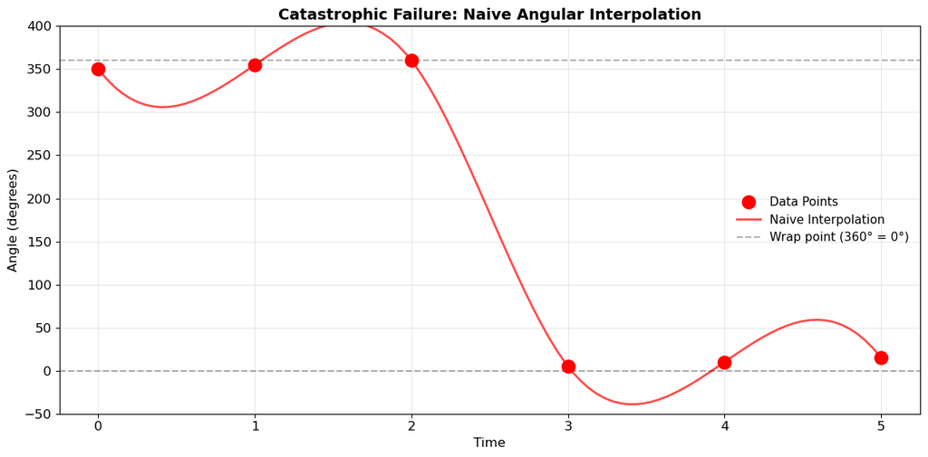

```python
# Visualize the catastrophic failure of naive angular interpolation
fig, ax = plt.subplots(figsize=(12, 6))

# Plot data points and wrong interpolation
ax.plot(test_times, test_angles, 'ro', markersize=12, label='Data Points', zorder=3)
ax.plot(dense_times, wrong_angles, 'r-', linewidth=2, label='Naive Interpolation', alpha=0.7)

# Mark the wrap point where 360° = 0°
ax.axhline(y=360, color='k', linestyle='--', alpha=0.3, label='Wrap point (360° = 0°)')
ax.axhline(y=0, color='k', linestyle='--', alpha=0.3)

# Labels and formatting
ax.set_xlabel('Time', fontsize=12)
ax.set_ylabel('Angle (degrees)', fontsize=12)
ax.set_title('Catastrophic Failure: Naive Angular Interpolation', fontsize=14, fontweight='bold')
ax.legend(fontsize=11, frameon=False)
ax.grid(True, alpha=0.3)
ax.set_ylim(-50, 400)  # Extended range to show the erroneous dip

plt.tight_layout()
plt.show()
```

The plot shows the disaster clearly. The interpolator sees [350, 355, 360, 5, 10, 15] and tries to draw a smooth curve through them, not knowing that 360° and 0° are the same direction. It creates an enormous dip from 360° down toward 0°, producing completely wrong intermediate values. Some interpolated values even go negative or exceed 360°, which is physically impossible for an azimuth angle.

### The Solution: Unwrap, Interpolate, Wrap

The solution is a three-step process that transforms the circular problem into a linear one:

1. **Unwrap**: Remove the artificial 360° jumps, treating the angle as if it continues past 360° instead of wrapping back to 0°. So [350, 355, 360, 5, 10, 15] becomes [350, 355, 360, 365, 370, 375] - now the interpolator sees a smooth increasing sequence.
2. **Interpolate**: Apply any interpolation method to the unwrapped values. They're now just regular numbers with no discontinuities.
3. **Wrap**: Apply modulo 360° to bring the interpolated values back to the standard [0°, 360°) range.

NumPy provides `np.unwrap()` to automatically detect and remove jumps. For degree data, we specify `period=360.0` to tell it the wrapping period - this is simpler than converting to radians and back.

Let's see the correct workflow step by step:

```python
# Step 1: Unwrap the angles directly in degrees
# np.unwrap() with period=360.0 detects jumps > 180° and adjusts by multiples of 360°
from typing import Any

unwrapped_deg = np.unwrap(test_angles, period=360.0)

# Display the unwrapping transformation
print("After unwrapping (in degrees):")

for t, orig, unwrap in zip(test_times, test_angles, unwrapped_deg):
    print(f"  Time {t}: {orig:6.1f}° → {unwrap:6.1f}° (unwrapped)")

# The unwrapped sequence is now continuous with no artificial jumps
print("\nNotice: 5° became 365°, 10° became 370°, etc.")
print("The sequence is now monotonically increasing with no jumps!")
```

```
After unwrapping (in degrees):
  Time 0:  350.0° →  350.0° (unwrapped)
  Time 1:  355.0° →  355.0° (unwrapped)
  Time 2:  360.0° →  360.0° (unwrapped)
  Time 3:    5.0° →  365.0° (unwrapped)
  Time 4:   10.0° →  370.0° (unwrapped)
  Time 5:   15.0° →  375.0° (unwrapped)

Notice: 5° became 365°, 10° became 370°, etc.
The sequence is now monotonically increasing with no jumps!
```

```python
# Step 2: Interpolate the unwrapped (continuous) values
# Now the interpolator sees a smooth, monotonic sequence with no discontinuities
right_interp = interpolate.interp1d(test_times, unwrapped_deg, kind='cubic')
right_angles_unwrapped = right_interp(dense_times)  # Evaluate on dense grid

# Display sample interpolated values (still unwrapped, before wrapping back)
print("Sample of interpolated UNWRAPPED values:")
for idx in sample_indices:
    print(f"  Time {dense_times[idx]:.2f}: {right_angles_unwrapped[idx]:.1f}°")

# The interpolated values now increase smoothly without any spurious excursions
print("\nThese values smoothly increase from 350° to 375° - no crazy jumps!")
```

```
Sample of interpolated UNWRAPPED values:
  Time 2.02: 360.1°
  Time 2.12: 360.6°
  Time 2.22: 361.1°
  Time 2.32: 361.6°
  Time 2.42: 362.1°
  Time 2.58: 362.9°
  Time 2.68: 363.4°
  Time 2.78: 363.9°
  Time 2.88: 364.4°
  Time 3.03: 365.2°

These values smoothly increase from 350° to 375° - no crazy jumps!
```

```python
# Step 3: Wrap angles back to the standard [0°, 360°) range
# Modulo 360 brings values like 365° back to 5°, 370° to 10°, etc.
right_angles = right_angles_unwrapped % 360

# Display the final wrapped values
print("Sample of final WRAPPED values:")
for idx in sample_indices:
    print(f"  Time {dense_times[idx]:.2f}: {right_angles_unwrapped[idx]:.1f}° → {right_angles[idx]:.1f}° (wrapped)")

# Now we have physically correct angles in the standard range
print("\nNow all values are in [0°, 360°) range and physically correct!")
```

```
Sample of final WRAPPED values:
  Time 2.02: 360.1° → 0.1° (wrapped)
  Time 2.12: 360.6° → 0.6° (wrapped)
  Time 2.22: 361.1° → 1.1° (wrapped)
  Time 2.32: 361.6° → 1.6° (wrapped)
  Time 2.42: 362.1° → 2.1° (wrapped)
  Time 2.58: 362.9° → 2.9° (wrapped)
  Time 2.68: 363.4° → 3.4° (wrapped)
  Time 2.78: 363.9° → 3.9° (wrapped)
  Time 2.88: 364.4° → 4.4° (wrapped)
  Time 3.03: 365.2° → 5.2° (wrapped)

Now all values are in [0°, 360°) range and physically correct!
```

Compare the wrong and right approaches side by side:

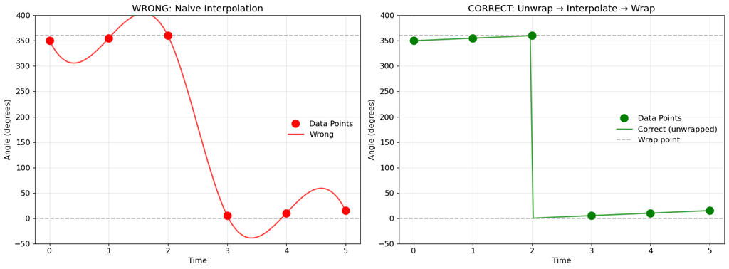

```python
# Create side-by-side comparison of wrong vs correct angular interpolation
fig, (ax1, ax2) = plt.subplots(1, 2, figsize=(16, 6))

# Left panel: WRONG approach (naive interpolation)
ax1.plot(test_times, test_angles, 'ro', markersize=12, label='Data Points', zorder=3)
ax1.plot(dense_times, wrong_angles, 'r-', linewidth=2, alpha=0.7, label='Wrong')
ax1.axhline(y=360, color='k', linestyle='--', alpha=0.3)  # Wrap point
ax1.axhline(y=0, color='k', linestyle='--', alpha=0.3)
ax1.set_xlabel('Time')
ax1.set_ylabel('Angle (degrees)')
ax1.set_title('WRONG: Naive Interpolation')
ax1.set_ylim(-50, 400)
ax1.legend(frameon=False)
ax1.grid(True, alpha=0.3)

# Right panel: CORRECT approach (unwrap → interpolate → wrap)
ax2.plot(test_times, test_angles, 'go', markersize=12, label='Data Points', zorder=3)
ax2.plot(dense_times, right_angles, 'g-', linewidth=2, label='Correct (unwrapped)', alpha=0.7)
ax2.axhline(y=360, color='k', linestyle='--', alpha=0.3, label='Wrap point')
ax2.axhline(y=0, color='k', linestyle='--', alpha=0.3)
ax2.set_xlabel('Time')
ax2.set_ylabel('Angle (degrees)')
ax2.set_title('CORRECT: Unwrap → Interpolate → Wrap')
ax2.set_ylim(-50, 400)
ax2.legend(frameon=False)
ax2.grid(True, alpha=0.3)

plt.tight_layout()
plt.show()
```

The left panel shows catastrophic failure with the interpolator creating a massive ~300-degree spurious excursion. The right panel shows smooth, physically correct interpolation - the angle increases smoothly from 350° through the wrap point (360° = 0°) to 15°, exactly as the physical motion demands.

### Applying the Solution to Our Azimuth Data

Now let's apply this unwrap-interpolate-wrap procedure to our actual Moon azimuth data and see how much the errors improve:

```python
# Apply the unwrap-interpolate-wrap procedure to our actual Moon azimuth data
# Step 1: Unwrap the sparse azimuth data (directly in degrees)
sparse_az_unwrapped = np.unwrap(sparse_az, period=360.0)  # Remove 360° jumps

# Step 2: Create corrected cubic spline interpolator using unwrapped values
az_interp_cubic_corrected = interpolate.interp1d(sparse_jd, sparse_az_unwrapped, kind='cubic')

# Step 3: Evaluate on test points and wrap results back to [0°, 360°)
interp_az_unwrapped = az_interp_cubic_corrected(test_jd_valid)  # Interpolate (unwrapped)
interp_az_corrected = interp_az_unwrapped % 360  # Wrap to standard range

print(f"Corrected azimuth interpolation complete!")
print(f"Handled {len(large_jumps)} wrap-around points in the data.")
```

```
Corrected azimuth interpolation complete!
Handled 6 wrap-around points in the data.
```

Calculate errors with the corrected interpolation, being careful to wrap the errors themselves to the [-180°, 180°] range:

```python
# Calculate corrected azimuth errors and compare with naive approach
az_errors_corrected = interp_az_corrected - true_az

# Wrap errors to [-180°, 180°] range for proper angular error calculation
# (an error of 350° should be interpreted as -10°, not +350°)
az_errors_corrected = (az_errors_corrected + 180) % 360 - 180

# Display comparison of error statistics
print("Comparison of azimuth interpolation errors:")
print(f"\nBEFORE (naive interpolation):")
print(f"  Mean absolute error: {np.mean(np.abs(az_errors)):.4f}°")
print(f"  Maximum error: {np.max(np.abs(az_errors)):.4f}°")
print(f"  RMS error: {np.sqrt(np.mean(az_errors**2)):.4f}°")

print(f"AFTER (with unwrap correction):")
print(f"  Mean absolute error: {np.mean(np.abs(az_errors_corrected)):.4f}°")
print(f"  Maximum error: {np.max(np.abs(az_errors_corrected)):.4f}°")
print(f"  RMS error: {np.sqrt(np.mean(az_errors_corrected**2)):.4f}°")

# Calculate percentage improvement
improvement = (np.mean(np.abs(az_errors)) - np.mean(np.abs(az_errors_corrected))) / np.mean(np.abs(az_errors)) * 100
print(f"\nImprovement: {improvement:.1f}% reduction in mean error!")
print(f"The corrected errors are now comparable to altitude errors (~1-7°).")
```

```
Comparison of azimuth interpolation errors:

BEFORE (naive interpolation):
  Mean absolute error: 39.5931°
  Maximum error: 303.8580°
  RMS error: 74.6194°
AFTER (with unwrap correction):
  Mean absolute error: 6.8181°
  Maximum error: 28.4311°
  RMS error: 8.9085°

Improvement: 82.8% reduction in mean error!
The corrected errors are now comparable to altitude errors (~1-7°).
```

Visualize the dramatic improvement with side-by-side error plots:

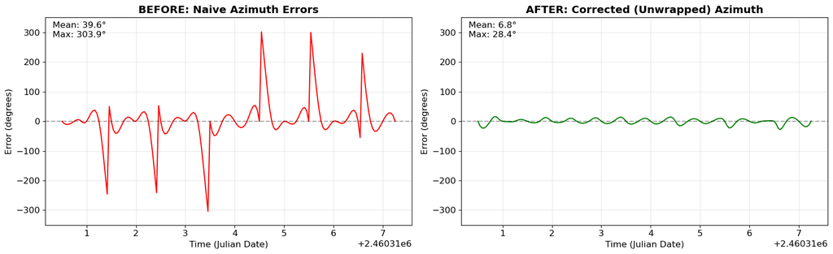

```
Notice the dramatic difference in error magnitudes!
Before: errors range ±300°
After: errors within ±28.4°
```

```python
# Visualize the dramatic improvement in azimuth errors with side-by-side comparison
fig, (ax1, ax2) = plt.subplots(1, 2, figsize=(16, 5))

# Left panel: BEFORE (naive interpolation with catastrophic errors)
ax1.plot(test_jd_valid, az_errors, 'r-', linewidth=1.5)
ax1.axhline(y=0, color='k', linestyle='--', alpha=0.3)  # Zero error line
ax1.set_xlabel('Time (Julian Date)')
ax1.set_ylabel('Error (degrees)')
ax1.set_title('BEFORE: Naive Azimuth Errors', fontweight='bold')
ax1.grid(True, alpha=0.3)
ax1.set_ylim(-350, 350)  # Same scale as right panel for fair comparison

# Add text box with error statistics
ax1.text(0.02, 0.98, f'Mean: {np.mean(np.abs(az_errors)):.1f}°\nMax: {np.max(np.abs(az_errors)):.1f}°',
         transform=ax1.transAxes, va='top')

# Right panel: AFTER (corrected unwrapped interpolation with much smaller errors)
ax2.plot(test_jd_valid, az_errors_corrected, 'g-', linewidth=1.5)
ax2.axhline(y=0, color='k', linestyle='--', alpha=0.3)  # Zero error line
ax2.set_xlabel('Time (Julian Date)')
ax2.set_ylabel('Error (degrees)')
ax2.set_title('AFTER: Corrected (Unwrapped) Azimuth', fontweight='bold')
ax2.grid(True, alpha=0.3)
ax2.set_ylim(-350, 350)  # Same scale as left panel for fair comparison
# Add text box with error statistics
ax2.text(0.02, 0.98, f'Mean: {np.mean(np.abs(az_errors_corrected)):.1f}°\nMax: {np.max(np.abs(az_errors_corrected)):.1f}°',
         transform=ax2.transAxes, va='top')

plt.tight_layout()
plt.show()

# Highlight the improvement
print(f"\nNotice the dramatic difference in error magnitudes!")
print(f"Before: errors range ±300°")
print(f"After: errors within ±{np.max(np.abs(az_errors_corrected)):.1f}°")
```

- **Denser sampling** (more data points) → smaller interpolation errors → more computation and storage
- **Sparser sampling** (fewer data points) → larger interpolation errors → less computation and storage

## Two-Dimensional Bivariate Interpolation

So far, we've been doing one-dimensional interpolation where we estimate altitude or azimuth as a function of time alone, at a single fixed location (Columbus, Ohio). But what if we want to answer a more complex question: **What is the Moon's altitude at a different latitude AND at a time between our measurements?**

This requires two-dimensional interpolation - estimating values as a function of two independent variables simultaneously. Instead of fitting polynomials along a line (1D), we fit polynomial surfaces over rectangular regions (2D). The concept extends naturally: in 1D interpolation, we create a curve in 2D space (y versus x), while in 2D interpolation, we create a surface in 3D space (z versus x and y).

**Important distinction:** "2D" refers to the **input space** (two input variables: latitude and time), not the output! The output is still a single value (altitude). If you need multiple outputs (e.g., altitude, azimuth, distance), simply create separate 2D interpolators for each output quantity.

SciPy provides `RectBivariateSpline` for smooth 2D interpolation on rectangular grids. The "rect" means our data must be on a rectangular grid (we need values at all combinations of our x and y points), while the "spline" means it uses smooth polynomial surfaces. We'll compute the Moon's altitude as seen from different latitudes at different times, creating a 2D grid, then interpolate to estimate altitude at (latitude, time) combinations **within the sampled range**. Note that spline extrapolation beyond your data grid can be inaccurate - always interpolate within the convex hull of your training points when possible.

Let's create a concrete 2D dataset. We'll compute the Moon's altitude as seen from different latitudes at different times. We'll use a denser sampling than before - 10 different observer latitudes (from 35°N to 45°N) to really showcase the interpolation quality:

```python
# Import 2D spline interpolation tool for functions of two variables
from scipy.interpolate import RectBivariateSpline

# Define a grid of observer latitudes from 35°N to 45°N (10 points)
# This covers a range of latitudes across the United States
lats_sparse = np.linspace(35, 45, 10)

# Count our grid dimensions
n_times = len(sparse_jd)  # Number of time points (28)
n_lats = len(lats_sparse)  # Number of latitude points (10)

# Display grid information
print(f"Setting up 2D grid:")
print(f"  Latitudes: {n_lats} points from {lats_sparse[0]}° to {lats_sparse[-1]}°")
print(f"  Times: {n_times} points")
print(f"  Total: {n_lats} × {n_times} = {n_lats * n_times} data points")
```

```
Setting up 2D grid:
  Latitudes: 10 points from 35.0° to 45.0°
  Times: 28 points
  Total: 10 × 28 = 280 data points
```

Now compute the Moon's altitude for each combination of latitude and time. We organize the results into a 2D array where `alt_grid[i, j]` is the altitude at latitude `i` and time `j`:

```python
# Create a 2D array to store altitude values: rows = latitudes, columns = times
alt_grid = np.zeros((n_lats, n_times))

# Loop over each latitude and compute Moon altitude at all times
for i, lat in enumerate(lats_sparse):

    # Create observer at this latitude (keeping same longitude and elevation)
    observer = earth + wgs84.latlon(lat, -83.0003, elevation_m=260)

    # Compute Moon positions as seen from this observer
    moon_obs = observer.at(times_sparse).observe(moon).apparent()
    alt, _, _ = moon_obs.altaz()

    # Store altitude values for this latitude (one row of the grid)
    alt_grid[i, :] = alt.degrees

print(f"\nComputed altitude grid with shape {alt_grid.shape}")
```

```
Computed altitude grid with shape (10, 28)
```

Create the 2D interpolator. The function `RectBivariateSpline` takes three arrays: `x` (latitudes), `y` (times), and `z` (altitudes). The parameters `kx=3` and `ky=3` specify cubic splines in both dimensions. Note that `RectBivariateSpline` requires the `x` and `y` arrays to be sorted in strictly increasing order (our `linspace` calls satisfy this automatically):

**Higher-dimensional interpolation:** For functions with 3 or more input variables, SciPy provides `RegularGridInterpolator` for rectangular grids (like `RectBivariateSpline` but for N dimensions) and `LinearNDInterpolator` or `NearestNDInterpolator` for scattered data in arbitrary dimensions. However, beware the "curse of dimensionality" - data requirements grow exponentially with dimensions!

```python
# Create a 2D cubic spline interpolator
# RectBivariateSpline(x, y, z, kx, ky) creates a surface z(x,y) through the data
# x = latitudes, y = times, z = altitudes
# kx=3, ky=3 means cubic splines in both dimensions
alt_interp_2d = RectBivariateSpline(lats_sparse, sparse_jd, alt_grid, kx=3, ky=3)

print("2D interpolator created!")
print("Can now estimate Moon altitude for ANY (latitude, time)")
```

```
2D interpolator created!
Can now estimate Moon altitude for ANY (latitude, time)
```

Let's test the interpolator with example queries at arbitrary points:

```python
# Test the 2D interpolator with example queries at arbitrary (latitude, time) points
test_queries = [
    (38.5, sparse_jd[0] + 0.5),  # Between latitude points, half day after start
    (42.0, sparse_jd[10] + 0.1),  # On latitude point, slightly after time point
    (40.0, sparse_jd[20]),        # Middle latitude, on time point
]

print("Test queries:")
for lat, jd in test_queries:
    # Get interpolated altitude
    alt_interp = alt_interp_2d(lat, jd)[0, 0]  # Returns 2D array, extract scalar

    # Compute true altitude with SkyField for validation
    observer_test = earth + wgs84.latlon(lat, -83.0003, elevation_m=260)
    time_test = ts.tt_jd(jd)
    alt_true = observer_test.at(time_test).observe(moon).apparent().altaz()[0].degrees

    # Calculate and display error
    error = alt_interp - alt_true
    print(f"  Lat={lat:5.1f}°, JD={jd:.3f}:")
    print(f"    Interpolated: {alt_interp:6.2f}°")
    print(f"    True: {alt_true:6.2f}°, Error: {error:+6.7f}°")
```

```
Test queries:
  Lat= 38.5°, JD=2460311.001:
    Interpolated:  48.35°
    True:  48.35°, Error: +0.0000001°
  Lat= 42.0°, JD=2460313.101:
    Interpolated:  29.49°
    True:  27.17°, Error: +2.3191687°
  Lat= 40.0°, JD=2460315.501:
    Interpolated: -63.34°
    True: -63.34°, Error: -0.0000002°
```

Let's visualize the 2D interpolation by creating a very dense grid covering the entire (latitude, time) space. We'll use 100 points in each dimension for smooth visualization:

```python
# Create dense grids in both dimensions for visualization
lats_dense_2d = np.linspace(35, 45, 100)  # 100 latitude points
times_dense_2d = np.linspace(sparse_jd[0], sparse_jd[-1], 200)  # 200 time points

# Evaluate the 2D interpolator on the dense grid
# This returns a 2D array of altitude values
alt_surface = alt_interp_2d(lats_dense_2d, times_dense_2d)

# Display information about the dense surface
print(f"Created dense surface:")
print(f"  {alt_surface.shape[0]} × {alt_surface.shape[1]} = {alt_surface.size} points")
print(f"  From {n_lats * n_times} original data points")
print(f"  That's a {alt_surface.size / (n_lats * n_times):.0f}× increase!")
```

```
Created dense surface:
  100 × 200 = 20000 points
  From 280 original data points
  That's a 71× increase!
```

Create a heatmap showing altitude as a function of both latitude and time:

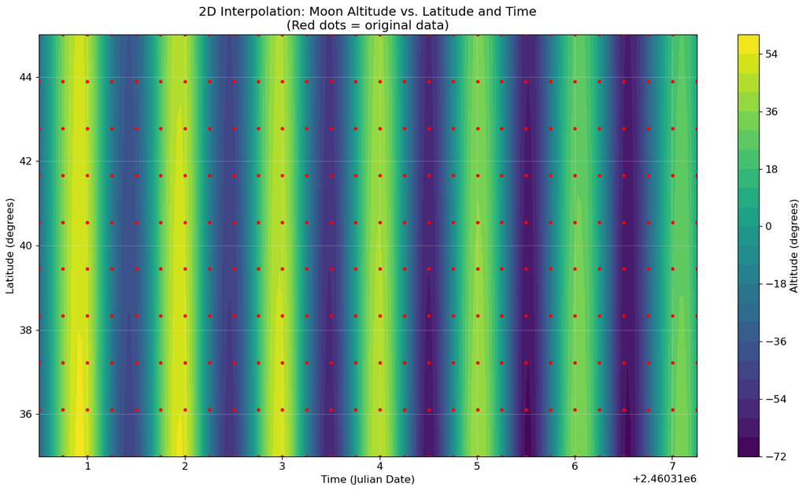

```python
# Create meshgrid for plotting the 2D surface
# np.meshgrid creates 2D coordinate arrays from 1D arrays
Times_mesh, Lats_mesh = np.meshgrid(times_dense_2d, lats_dense_2d)

# Create a color-filled contour plot (heatmap) of altitude
fig, ax = plt.subplots(figsize=(14, 8))

# Plot the interpolated surface as a filled contour plot
# levels=20 creates 20 contour levels, cmap='viridis' sets the color scheme
contour = ax.contourf(Times_mesh, Lats_mesh, alt_surface, levels=20, cmap='viridis')
cbar = plt.colorbar(contour, ax=ax, label='Altitude (degrees)')

# Overlay the original sparse data points as red dots
for i, lat in enumerate(lats_sparse):
    ax.plot(sparse_jd, np.full_like(sparse_jd, lat), 'r.', markersize=6)

# Labels and formatting
ax.set_xlabel('Time (Julian Date)')
ax.set_ylabel('Latitude (degrees)')
ax.set_title('2D Interpolation: Moon Altitude vs. Latitude and Time\n(Red dots = original data)')
ax.grid(True, alpha=0.2, color='white')

plt.tight_layout()
plt.show()
```

The visualization dramatically demonstrates the power of 2D interpolation. The smooth color gradients show how altitude varies continuously with both latitude and time. The red dots mark our original 280 data points, but the interpolator lets us estimate altitude at any of the 20,000 points in our dense grid. Notice the structure - you can see the Moon rising and setting (vertical bands), and how maximum altitude changes with latitude and time.

## Numerical Differentiation - Finding Rates of Change

Differentiation tells us how fast something is changing. If position is our function, the derivative gives us velocity. If we have temperature versus time, the derivative tells us the rate of heating or cooling. In calculus, you learned that the derivative is the instantaneous rate of change:

$$\frac{df}{dx} = \lim_{h \to 0} \frac{f(x+h) - f(x)}{h},$$

which is the slope of the tangent line at that point. With discrete data, we need numerical methods to approximate derivatives. The simplest approach is **finite differences**, where you directly compute $\frac{f(x+h) - f(x)}{h}$ using adjacent data points. We saw this in the last lecture using `np.diff()` to compute differences between consecutive elements. While easy to implement, finite differences have a major drawback: they amplify noise in your data.

Since we're already using splines for interpolation, it makes much more sense to use **spline-based differentiation**. SciPy provides powerful spline-based differentiation tools that are generally more accurate and robust than finite differences, especially for noisy data. The key advantage of spline-based methods is that they first fit a smooth curve through your data, then differentiate that curve analytically. This removes much of the noise amplification that plagues simple finite difference methods.

### SciPy's Spline-Based Differentiation

SciPy provides powerful spline-based differentiation through `scipy.interpolate.CubicSpline` objects, which have built-in derivative methods. This is the same interpolation approach we used earlier with `interp1d` - it fits a smooth cubic spline through your data points. The key difference is that `CubicSpline` objects also allow us to compute derivatives of that spline analytically. Since the spline is a piecewise polynomial, its derivatives can be computed exactly. This is much more robust than finite differences, which can amplify noise. Let's use `CubicSpline` to compute derivatives of the Moon's altitude:

```python
# Import CubicSpline for differentiation
from scipy.interpolate import CubicSpline

# Create a CubicSpline object from our sparse altitude data
# This fits a smooth cubic polynomial curve through all data points
cs_alt = CubicSpline(sparse_jd, sparse_alt)

# Compute first derivative (velocity) at sparse time points
# CubicSpline(x, nu) evaluates the nu-th derivative: nu=0 is function itself, nu=1 is first derivative, nu=2 is second derivative
dalt_dt_cubic = cs_alt(sparse_jd, nu=1)  # First derivative in degrees per day

# Compute second derivative (acceleration) at sparse time points
d2alt_dt2_cubic = cs_alt(sparse_jd, nu=2)  # Second derivative in degrees per day²

# Convert derivatives from per-day to per-hour for more intuitive units
dalt_dt_cubic_per_hour = dalt_dt_cubic / 24  # degrees per hour
d2alt_dt2_cubic_per_hour2 = d2alt_dt2_cubic / (24**2)  # degrees per hour²

# Display statistics about the computed derivatives
print("\nSciPy CubicSpline method:")
print(f"  First derivative (velocity): [{np.min(dalt_dt_cubic_per_hour):.3f}, {np.max(dalt_dt_cubic_per_hour):.3f}] deg/hour")
print(f"  Second derivative (acceleration): [{np.min(d2alt_dt2_cubic_per_hour2):.5f}, {np.max(d2alt_dt2_cubic_per_hour2):.5f}] deg/hour²")
```

```
SciPy CubicSpline method:
  First derivative (velocity): [-13.538, 11.908] deg/hour
  Second derivative (acceleration): [-4.44992, 4.54366] deg/hour²
```

Now let's visualize position, velocity, and acceleration together on a dense grid. Since we're using cubic splines, we can evaluate the function and its derivatives smoothly at any point, not just at our sparse data points. This three-panel plot shows how these quantities are related through differentiation:

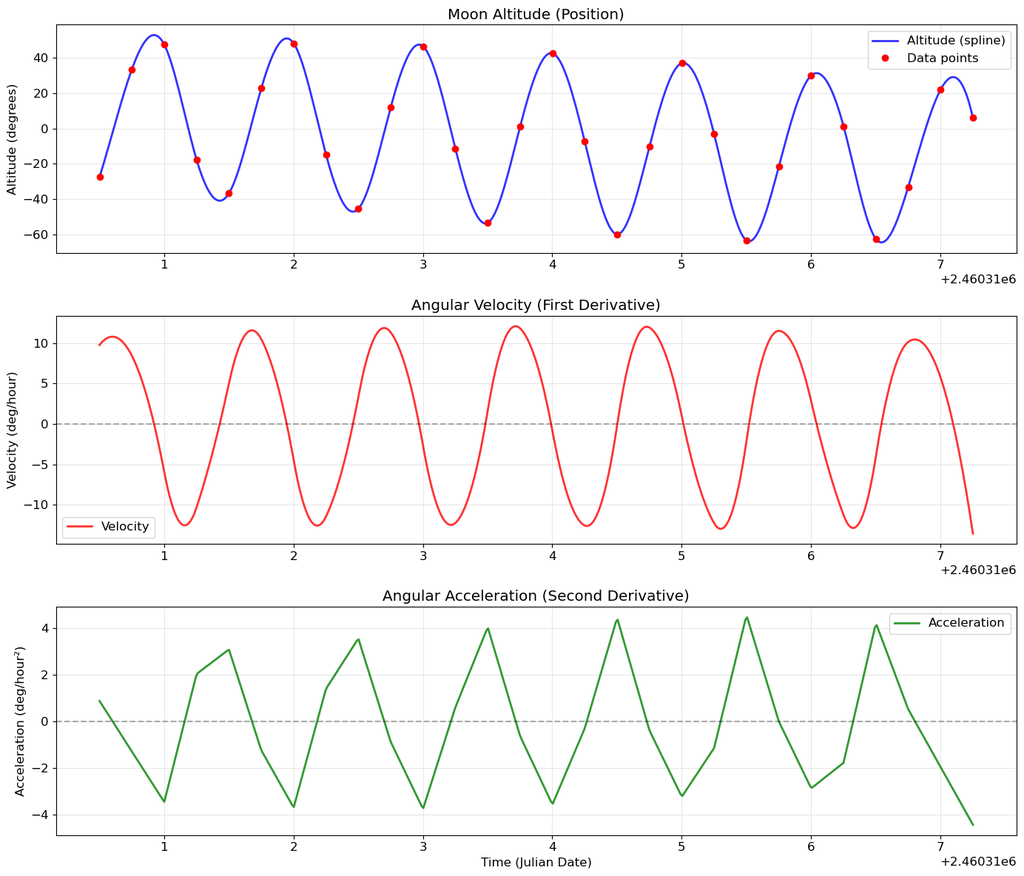

```python
# Create a dense time grid for smooth visualization of the cubic spline
dense_jd_viz = np.linspace(sparse_jd[0], sparse_jd[-1], 500)

# Evaluate position (altitude) and derivatives on the dense grid
dense_alt_viz = cs_alt(dense_jd_viz)  # Position (altitude)
dense_vel_viz = cs_alt(dense_jd_viz, nu=1) / 24  # First derivative (velocity) in deg/hour
dense_acc_viz = cs_alt(dense_jd_viz, nu=2) / (24**2)  # Second derivative (acceleration) in deg/hour²

# Create a three-panel figure showing smooth curves from the cubic spline
fig, (ax1, ax2, ax3) = plt.subplots(3, 1, figsize=(14, 12))

# Top panel: Position (altitude) - smooth curve with original data points
ax1.plot(dense_jd_viz, dense_alt_viz, 'b-', linewidth=2, label='Altitude (spline)', alpha=0.8)
ax1.plot(sparse_jd, sparse_alt, 'ro', markersize=6, label='Data points')
ax1.set_ylabel('Altitude (degrees)')
ax1.set_title('Moon Altitude (Position)')
ax1.grid(True, alpha=0.3)
ax1.legend()

# Middle panel: First derivative (velocity) - smooth curve showing rate of altitude change
ax2.plot(dense_jd_viz, dense_vel_viz, 'r-', linewidth=2, label='Velocity', alpha=0.8)
ax2.axhline(y=0, color='k', linestyle='--', alpha=0.3)  # Mark zero velocity line
ax2.set_ylabel('Velocity (deg/hour)')
ax2.set_title('Angular Velocity (First Derivative)')
ax2.grid(True, alpha=0.3)
ax2.legend()

# Bottom panel: Second derivative (acceleration) - shows how velocity is changing
ax3.plot(dense_jd_viz, dense_acc_viz, 'g-', linewidth=2, label='Acceleration', alpha=0.8)
ax3.axhline(y=0, color='k', linestyle='--', alpha=0.3)  # Mark zero acceleration line
ax3.set_xlabel('Time (Julian Date)')
ax3.set_ylabel('Acceleration (deg/hour²)')
ax3.set_title('Angular Acceleration (Second Derivative)')
ax3.grid(True, alpha=0.3)
ax3.legend()

plt.tight_layout()
plt.show()
```

**Why does the acceleration (second derivative) look jagged?** This is expected behavior for cubic splines! A cubic polynomial has the form $s(t) = a_3t^3 + a_2t^2 + a_1t + a_0$. Taking derivatives:

- First derivative: $s'(t) = 3a_3t^2 + 2a_2t + a_1$ (quadratic - smooth and continuous)
- Second derivative: $s''(t) = 6a_3t + 2a_2$ (linear - continuous but not smooth)

So the acceleration is piecewise linear with slope discontinuities (kinks) at each of our 28 data points. The function $s(t)$ and first derivative $s'(t)$ are smooth (continuously differentiable), but the second derivative $s''(t)$ is only continuous, not smooth. If you need smoother higher derivatives, you'd use quintic (degree 5) splines instead, where $s''(t)$ would be cubic and thus smooth, but cubic splines are the standard compromise between smoothness and computational cost.

### Finding Extrema with Derivatives

An important application of derivatives is finding extrema - maximum and minimum points. From calculus, we know that at a local maximum or minimum, the derivative equals zero: $\frac{dh}{dt} = 0$, where $h(t)$ is altitude. This is because at a peak, the function momentarily stops increasing and starts decreasing (or vice versa at a minimum). Mathematically, if $h(t)$ has a local extremum at $t = t_0$, then $h'(t_0) = 0$ and the sign of $h''(t_0)$ tells us whether it's a maximum ($h''(t_0) < 0$) or minimum ($h''(t_0) > 0$).

We can use this property to find when the Moon reaches its highest point in the sky (culmination). To find where velocity crosses zero, we use a clever numerical trick: `np.sign()` combined with `np.diff()` and `np.where()`. This approach is much smarter than checking if values are exactly zero (which rarely happens with floating-point numbers) or manually comparing consecutive values.

The `np.sign()` function converts each number to -1 (negative), 0 (zero), or +1 (positive), effectively reducing our velocity array to just its sign pattern. Then `np.diff(np.sign(array))` computes differences between consecutive sign values. When velocity changes from positive to negative at a maximum, the sign goes from +1 to -1, giving a difference of -2. When velocity changes from negative to positive at a minimum, the sign goes from -1 to +1, giving a difference of +2. When velocity stays the same sign, the difference is 0.

Finally, `np.where()` finds the indices where these sign changes occur. The function `np.where(condition)` returns a tuple of arrays containing the indices where the condition is True. In our case, `np.where(np.diff(np.sign(dense_vel_for_extrema)))` finds all indices where the difference is non-zero (any sign change). Since we're working with a 1D array, `np.where()` returns a tuple with one array, so we extract it with `[0]`. These indices tell us the positions in our dense grid where velocity crosses zero - exactly where the extrema occur. This method automatically detects all zero-crossings regardless of whether they're maxima or minima, and works robustly even with noisy data:

```python
# Create a dense time grid for finding where velocity crosses zero (extrema)
dense_jd_for_extrema = np.linspace(sparse_jd[0], sparse_jd[-1], 1000)

# Evaluate velocity on this dense grid
dense_vel_for_extrema = cs_alt(dense_jd_for_extrema, nu=1) / 24

# Find indices where velocity changes sign (crosses zero)
# np.sign() gives -1, 0, or 1; np.diff() finds where this changes
sign_changes = np.where(np.diff(np.sign(dense_vel_for_extrema)))[0]
extrema_indices = sign_changes  # Store for later comparison with find_peaks

print(f"Found {len(extrema_indices)} extrema\n")

# For each sign change, refine the zero-crossing location using linear interpolation
for idx in sign_changes:
    # Get the two points bracketing the zero crossing
    t1, t2 = dense_jd_for_extrema[idx], dense_jd_for_extrema[idx+1]
    v1, v2 = dense_vel_for_extrema[idx], dense_vel_for_extrema[idx+1]

    # Linear interpolation to find where velocity = 0
    t_cross = t1 - v1 * (t2 - t1) / (v2 - v1)

    # Evaluate altitude at the zero crossing
    alt_at_cross = cs_alt(t_cross)

    # Determine if this is a maximum or minimum based on sign of velocity before crossing
    extremum_type = "maximum" if dense_vel_for_extrema[idx] > 0 else "minimum"

    # Convert Julian date to human-readable format
    t_obj = ts.tt_jd(t_cross)
    print(f"  {extremum_type.capitalize()} at {t_obj.utc_strftime('%Y-%m-%d %H:%M')}")
    print(f"    Altitude = {alt_at_cross:.2f}°")
```

```
Found 13 extrema

  Maximum at 2024-01-01 10:06
    Altitude = 52.89°
  Minimum at 2024-01-01 22:17
    Altitude = -40.89°
  Maximum at 2024-01-02 10:43
    Altitude = 50.99°
  Minimum at 2024-01-02 23:00
    Altitude = -47.09°
  Maximum at 2024-01-03 11:15
    Altitude = 47.47°
  Minimum at 2024-01-03 23:35
    Altitude = -53.75°
  Maximum at 2024-01-04 11:45
    Altitude = 42.72°
  Minimum at 2024-01-05 00:02
    Altitude = -59.85°
  Maximum at 2024-01-05 12:18
    Altitude = 37.10°
  Minimum at 2024-01-06 00:29
    Altitude = -63.87°
  Maximum at 2024-01-06 13:00
    Altitude = 31.34°
  Minimum at 2024-01-07 01:02
    Altitude = -64.49°
  Maximum at 2024-01-07 14:20
    Altitude = 29.11°
```

This derivative zero-crossing approach works well and teaches the underlying mathematics - we found 13 extrema (7 maxima and 6 minima alternating). This technique is fundamental to optimization throughout science and engineering.

### A Better Way: Built-in Peak Detection

While finding derivative zeros is educational, SciPy provides a purpose-built tool that's more convenient for practical applications: `scipy.signal.find_peaks`. This function is specifically designed to find local maxima with customizable constraints:

**Key Parameters of `find_peaks`:**

- **`prominence`**: How much a peak must stand out from its surrounding baseline (in the same units as your data). A peak with prominence 10 means it rises 10° above the lowest point between it and neighboring peaks. This filters out small bumps.
- **`distance`**: Minimum number of samples between detected peaks. Useful when you know peaks should be separated by a certain time/space interval. For our Moon data with 1000 samples over 7 days, `distance=100` means peaks must be ~16 hours apart.
- **`height`**: Minimum absolute value for a peak. We use `height=20` to only detect transits when the Moon is significantly above the horizon (20° altitude).

These parameters let you tune peak detection for your specific scientific application. Let's use them to find the same transit events we identified with derivatives:

```python
# Import signal processing tools for peak detection
from scipy import signal

# Use the SAME data grid as before for fair comparison
# (We already have dense_jd_for_extrema and can evaluate altitude on it)
alt_for_peak_detection = cs_alt(dense_jd_for_extrema)

# Find peaks (local maxima only) in the altitude data with constraints:
# - prominence: how much a peak stands out from the surrounding baseline
# - distance: minimum separation between peaks (in samples)
# - height: minimum altitude value to consider as a peak
peaks, properties = signal.find_peaks(
    alt_for_peak_detection,
    prominence=10,  # Peak must rise at least 10° above surroundings
    distance=100,   # Peaks separated by at least 100 samples (~16 hours for 1000-point grid)
    height=20       # Only peaks above 20° altitude (significantly above horizon)
)

print(f"scipy.signal.find_peaks found: {len(peaks)} altitude maxima")
print(f"Derivative zero-crossing found: 7 maxima (plus 6 minima)")
print(f"\n✓ Both methods found the same {len(peaks)} transit events!")
print("\nDetailed transit times:")
print("="*50)
for i, peak_idx in enumerate(peaks):
    # Extract time and altitude at this peak
    t_peak = dense_jd_for_extrema[peak_idx]  # Time in Julian Date
    alt_peak = alt_for_peak_detection[peak_idx]  # Altitude in degrees

    # Convert Julian Date to human-readable format
    peak_date = ts.tt_jd(t_peak)

    print(f"Transit {i+1}:")
    print(f"  Time (JD): {t_peak:.3f} ({(t_peak - sparse_jd[0]):.2f} days from start)")
    print(f"  Maximum altitude: {alt_peak:.1f}°")
    print(f"  Date: {peak_date.utc_strftime('%Y-%m-%d %H:%M UTC')}")
    print()
```

```
scipy.signal.find_peaks found: 7 altitude maxima
Derivative zero-crossing found: 7 maxima (plus 6 minima)

✓ Both methods found the same 7 transit events!

Detailed transit times:
==================================================
Transit 1:
  Time (JD): 2460310.920 (0.42 days from start)
  Maximum altitude: 52.9°
  Date: 2024-01-01 10:03 UTC

Transit 2:
  Time (JD): 2460311.947 (1.45 days from start)
  Maximum altitude: 51.0°
  Date: 2024-01-02 10:42 UTC

Transit 3:
  Time (JD): 2460312.967 (2.47 days from start)
  Maximum altitude: 47.5°
  Date: 2024-01-03 11:11 UTC

Transit 4:
  Time (JD): 2460313.987 (3.49 days from start)
  Maximum altitude: 42.7°
  Date: 2024-01-04 11:41 UTC

Transit 5:
  Time (JD): 2460315.014 (4.51 days from start)
  Maximum altitude: 37.1°
  Date: 2024-01-05 12:19 UTC

Transit 6:
  Time (JD): 2460316.041 (5.54 days from start)
  Maximum altitude: 31.3°
  Date: 2024-01-06 12:58 UTC

Transit 7:
  Time (JD): 2460317.095 (6.59 days from start)
  Maximum altitude: 29.1°
  Date: 2024-01-07 14:16 UTC
```

The `find_peaks` function is easier to use and specifically targets maxima (we don't need to manually filter alternating extrema). Let's visualize these peaks to confirm they match the transit times we found earlier:

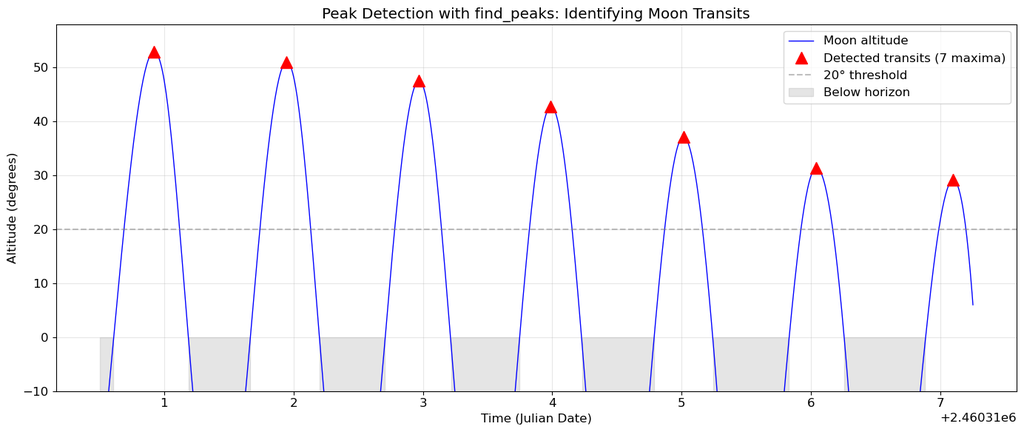

```python
# Create visualization showing altitude curve with detected peaks
fig, ax = plt.subplots(figsize=(14, 6))

# Plot the continuous altitude curve on our dense time grid
ax.plot(dense_jd_for_extrema, alt_for_peak_detection, 'b-', linewidth=1, label='Moon altitude')

# Mark the detected peaks with red triangles (from find_peaks)
ax.plot(dense_jd_for_extrema[peaks], alt_for_peak_detection[peaks], 'r^',
        markersize=12, label=f'Detected transits ({len(peaks)} maxima)', zorder=5)

# Add horizontal line showing our 20° threshold used in peak detection
ax.axhline(y=20, color='gray', linestyle='--', alpha=0.5, label='20° threshold')

# Shade the region where Moon is below the horizon (negative altitude)
below_horizon = alt_for_peak_detection < 0
ax.fill_between(dense_jd_for_extrema, -10, 0, where=below_horizon,
                alpha=0.2, color='gray', label='Below horizon')

# Label axes and add title
ax.set_xlabel('Time (Julian Date)')
ax.set_ylabel('Altitude (degrees)')
ax.set_title('Peak Detection with find_peaks: Identifying Moon Transits')
ax.legend(loc='upper right')
ax.grid(True, alpha=0.3)
ax.set_ylim(-10, max(alt_for_peak_detection) + 5)  # Set y-axis range to show all data

plt.tight_layout()
plt.show()
```

For finding astronomical transits, local maxima of specific phenomena, or peaks in spectra, `find_peaks` is usually more convenient. However, understanding the derivative approach teaches you the mathematical foundations that underlie all optimization methods you'll encounter in future lectures.

## Numerical Integration - Computing Totals

Integration is the opposite of differentiation. Instead of finding rates of change, we're accumulating quantities over time. If velocity is our function, integration gives us distance traveled. If we have power consumption over time, integration gives us total energy used. In calculus, the definite integral represents the signed area under the curve: $$\int_a^b f(x)\,dx$$ which equals the area between the curve $f(x)$ and the x-axis from $a$ to $b$.

With discrete data, we approximate this area using numerical quadrature methods. The fundamental idea is to divide the region into small pieces, approximate the area of each piece using simple geometric shapes, then sum all the pieces. The two most common approaches are the trapezoidal rule (which approximates each segment as a trapezoid) and Simpson's rule (which uses parabolic curves for better accuracy on smooth functions). Let's explore both methods and see how they compare.

### Setting Up for Integration

Let's compute the total angular distance the Moon travels across the sky by integrating its angular velocity. Remember from physics that integrating velocity gives displacement, or in our case, total angular distance. We'll use the absolute value of velocity because we care about total motion, not net displacement:

```python
# Import SciPy's numerical integration module
from scipy import integrate

# Compute angular speed (absolute value of velocity) from our cubic spline
# cs_alt(sparse_jd, 1) gives derivative in deg/day, divide by 24 for deg/hour
# (cs_alt is the CubicSpline interpolator we created for altitude)
# Use absolute value because we want total distance traveled, not net displacement
angular_speed = np.abs(cs_alt(sparse_jd, nu=1) / 24)

# Convert time from Julian dates to hours from start for easier interpretation
time_hours = (sparse_jd - sparse_jd[0]) * 24

# Display summary of data we'll integrate
print(f"Data ready for integration:")
print(f"  {len(angular_speed)} velocity measurements")
print(f"  Time span: {time_hours[-1]:.1f} hours = {time_hours[-1]/24:.1f} days")
print(f"  Average speed: {np.mean(angular_speed):.3f} deg/hour")
print(f"\nWe'll integrate speed to find total distance traveled")
```

```
Data ready for integration:
  28 velocity measurements
  Time span: 162.0 hours = 6.8 days
  Average speed: 7.446 deg/hour

We'll integrate speed to find total distance traveled
```

### The Trapezoidal Rule

The trapezoidal rule is the simplest and most robust integration method. Between each pair of adjacent points, it approximates the area as a trapezoid - a four-sided shape with two parallel sides. The formula for the area of one trapezoid segment is $$\text{Area}_i = \frac{y_i + y_{i+1}}{2} \times (x_{i+1} - x_i).$$

This is just the average height times the width. The total integral is the sum of all these trapezoidal areas. Geometrically, you're filling the space under the curve with trapezoids that touch the curve at the data points. SciPy's `integrate.trapezoid()` (formerly `trapz()`) implements this automatically, handling all the indexing and summing for you:

Let's start with a simple example to see the trapezoidal rule in action. We'll integrate $f(x) = x^2$ from 0 to 4 using just 5 points. The true answer is $\int_0^4 x^2\,dx = \frac{x^3}{3}\big|_0^4 = \frac{64}{3} \approx 21.33$:

```
Trapezoidal rule result: 22.00
True integral:           21.33
Error:                   0.67 (3.1%)
```

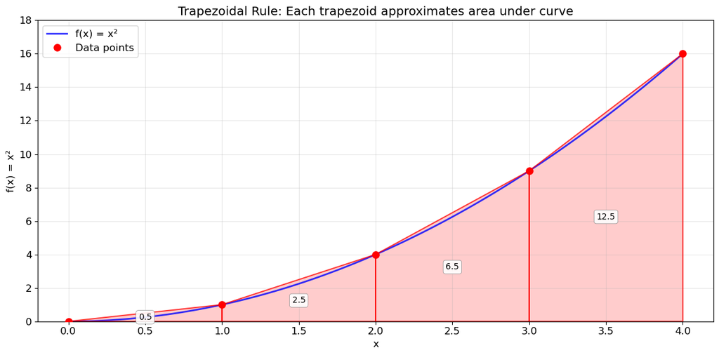

```
Sum of trapezoid areas: 0.5 + 2.5 + 6.5 + 12.5 = 22.0
```

```python
# Simple example: integrate f(x) = x² from 0 to 4
x_simple = np.array([0, 1, 2, 3, 4])  # Just 5 points
y_simple = x_simple**2  # f(x) = x²

# Apply trapezoidal rule
integral_trapz = integrate.trapezoid(y_simple, x_simple)

# True answer from calculus
true_integral = 64/3  # x³/3 evaluated from 0 to 4

print(f"Trapezoidal rule result: {integral_trapz:.2f}")
print(f"True integral:           {true_integral:.2f}")
print(f"Error:                   {abs(integral_trapz - true_integral):.2f} ({abs(integral_trapz - true_integral)/true_integral*100:.1f}%)")

# Visualize the trapezoidal approximation
fig, ax = plt.subplots(figsize=(12, 6))

# Plot the smooth true function
x_smooth = np.linspace(0, 4, 100)
y_smooth = x_smooth**2
ax.plot(x_smooth, y_smooth, 'b-', linewidth=2, label='f(x) = x²', alpha=0.8)

# Plot the data points
ax.plot(x_simple, y_simple, 'ro', markersize=8, label='Data points', zorder=5)

# Draw each trapezoid
for i in range(len(x_simple)-1):
    # Vertices of the trapezoid: bottom-left, top-left, top-right, bottom-right
    x_trap = [x_simple[i], x_simple[i], x_simple[i+1], x_simple[i+1], x_simple[i]]
    y_trap = [0, y_simple[i], y_simple[i+1], 0, 0]
    ax.plot(x_trap, y_trap, 'r-', linewidth=1.5, alpha=0.7)
    ax.fill(x_trap, y_trap, color='red', alpha=0.2)

    # Calculate and display area of this trapezoid
    area = (y_simple[i] + y_simple[i+1]) * (x_simple[i+1] - x_simple[i]) / 2
    mid_x = (x_simple[i] + x_simple[i+1]) / 2
    mid_y = (y_simple[i] + y_simple[i+1]) / 4
    ax.text(mid_x, mid_y, f'{area:.1f}', ha='center', va='center',
            fontsize=10, bbox=dict(boxstyle='round,pad=0.3',
            facecolor='white', edgecolor='gray', alpha=0.9, linewidth=0.5))

ax.set_xlabel('x')
ax.set_ylabel('f(x) = x²')
ax.set_title('Trapezoidal Rule: Each trapezoid approximates area under curve')
ax.legend()
ax.grid(True, alpha=0.3)
ax.set_ylim(0, 18)

plt.tight_layout()
plt.show()

print(f"\nSum of trapezoid areas: {' + '.join([f'{(y_simple[i] + y_simple[i+1]) * (x_simple[i+1] - x_simple[i]) / 2:.1f}' for i in range(len(x_simple)-1)])} = {integral_trapz:.1f}")
```

Now let's apply this to our Moon data:

```python
# Use the trapezoidal rule to integrate angular speed over time
# integrate.trapezoid(y, x) computes the integral of y with respect to x
# This gives us total angular distance traveled (in degrees)
total_distance_trapz = integrate.trapezoid(angular_speed, time_hours)

# Display the integration result
print(f"Trapezoidal rule result:")
print(f"  Total angular distance: {total_distance_trapz:.2f}°")
print(f"  Average speed over period: {total_distance_trapz / time_hours[-1]:.3f} deg/hour")

# Provide context for the result
print(f"\nFor reference:")
print(f"  Moon's diameter: ~0.5°")
print(f"  So the Moon moved {total_distance_trapz/0.5:.0f} Moon-diameters!")
```

```
Trapezoidal rule result:
  Total angular distance: 1181.00°
  Average speed over period: 7.290 deg/hour

For reference:
  Moon's diameter: ~0.5°
  So the Moon moved 2362 Moon-diameters!
```

The same principle applies to our Moon data, but with 28 data points over the week. Here's what it looks like:

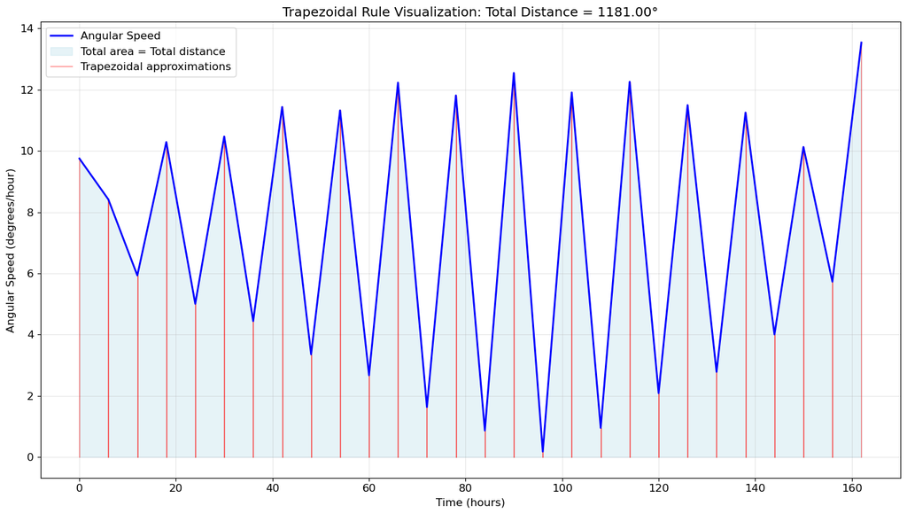

```python
# Visualize the trapezoidal rule geometrically
fig, ax = plt.subplots(figsize=(14, 8))

# Plot the speed curve (the function we're integrating)
ax.plot(time_hours, angular_speed, 'b-', linewidth=2, label='Angular Speed', zorder=3)
# Fill the area under the curve (this area represents the integral)
ax.fill_between(time_hours, 0, angular_speed, alpha=0.3, color='lightblue', label='Total area = Total distance')

# Draw the individual trapezoids used in the approximation
for i in range(len(time_hours)-1):
    # Top edge of trapezoid (connects two adjacent function values)
    ax.plot([time_hours[i], time_hours[i+1]], [angular_speed[i], angular_speed[i+1]], 'r-', linewidth=1, alpha=0.5)
    # Left edge of trapezoid (vertical line at left point)
    ax.plot([time_hours[i], time_hours[i]], [0, angular_speed[i]], 'r-', linewidth=1, alpha=0.5)
    # Right edge of trapezoid (vertical line at right point)
    ax.plot([time_hours[i+1], time_hours[i+1]], [0, angular_speed[i+1]], 'r-', linewidth=1, alpha=0.5)

# Add legend entry for the trapezoid outlines
ax.plot([], [], 'r-', linewidth=1, alpha=0.5, label='Trapezoidal approximations')

# Labels and formatting
ax.set_xlabel('Time (hours)')
ax.set_ylabel('Angular Speed (degrees/hour)')
ax.set_title(f'Trapezoidal Rule Visualization: Total Distance = {total_distance_trapz:.2f}°')
ax.legend()
ax.grid(True, alpha=0.3)

plt.tight_layout()
plt.show()
```

### Simpson's Rule: Parabolic Approximation

Simpson's rule is more sophisticated than the trapezoidal rule. Instead of approximating the curve with straight lines (trapezoids), it fits parabolas (quadratic curves) through groups of three consecutive points.

Mathematically, for each interval from $x_i$ to $x_{i+2}$, Simpson's rule fits a quadratic polynomial $P(x) = ax^2 + bx + c$ through the three points $(x_i, f(x_i))$, $(x_{i+1}, f(x_{i+1}))$, and $(x_{i+2}, f(x_{i+2}))$. It then integrates this polynomial exactly:

$$\int_{x_i}^{x_{i+2}} f(x) \, dx \approx \int_{x_i}^{x_{i+2}} P(x) \, dx = \frac{h}{3}\left[f(x_i) + 4f(x_{i+1}) + f(x_{i+2})\right]$$

where $h = (x_{i+2} - x_i)/2$ is the spacing between points. The famous "1-4-1" weighting pattern emerges from the exact integration of the parabola. Because parabolas can match both the slope and curvature of the underlying function, Simpson's rule typically provides much better accuracy than the trapezoidal rule for smooth functions with reasonably dense sampling.

**When does Simpson's rule excel?** It achieves higher-order accuracy when:

1. The function is smooth (continuous derivatives)
2. Sampling is reasonably dense relative to the function's variation
3. Grid spacing is fairly uniform

On very sparse, nonuniform, or noisy data, Simpson's accuracy advantage may diminish. For our smooth, well-sampled Moon ephemeris data, it should work excellently.

The tradeoff is that Simpson's rule requires an odd number of points (or it ignores the last point if you have an even number) and is slightly more computationally expensive. For our Moon data with 28 points, SciPy will apply Simpson's rule to the first 27 points and handle the last interval separately:

```python
# Use Simpson's rule for comparison (more accurate for smooth functions)
# Simpson's rule fits parabolas through triplets of points instead of straight lines
total_distance_simpson = integrate.simpson(angular_speed, time_hours)

print(f"Simpson's rule result:")
print(f"  Total angular distance: {total_distance_simpson:.2f}°")

# Compare the two methods
print(f"\nComparison of integration methods:")
print(f"  Trapezoidal: {total_distance_trapz:.4f}°")
print(f"  Simpson:     {total_distance_simpson:.4f}°")
print(f"  Difference:  {abs(total_distance_trapz - total_distance_simpson):.4f}°")
print(f"  Relative difference: {abs(total_distance_trapz - total_distance_simpson) / total_distance_simpson * 100:.3f}%")
print(f"\nThe two methods agree very closely!")
```

[output not shown]

### Cumulative Integration: Running Totals

Sometimes we want to see how a quantity accumulates over time, not just the final total. This is called cumulative integration. While definite integration gives us a single number $\int_a^b f(x) \, dx$, cumulative integration gives us a function:

$$F(t) = \int_a^t f(x) \, dx$$

This represents the accumulated value from the starting point $a$ up to any time $t$. For our Moon example, if $v(t)$ is the angular speed, then the cumulative distance is:

$$D(t) = \int_0^t v(\tau) \, d\tau$$

SciPy provides `cumulative_trapezoid()` which computes this running total at each data point using the trapezoidal rule. For discrete data points, this means:

$$D(t_i) = \sum_{j=1}^{i} \frac{h}{2}\left[v(t_{j-1}) + v(t_j)\right]$$

This shows the cumulative angular distance traveled as a function of time - we can see exactly how much the Moon has moved by any given moment. This is particularly useful for understanding how quickly quantities accumulate and identifying periods of rapid or slow accumulation:

```python
# Compute cumulative (running total) integration
# cumulative_trapezoid returns the integral from start up to each point
# initial=0 ensures the array has the same length as time_hours (starts at 0)
cumulative_distance = integrate.cumulative_trapezoid(angular_speed, time_hours, initial=0)

# Display information about the cumulative result
print(f"Cumulative integration:")
print(f"  Initial distance (t=0): {cumulative_distance[0]:.2f}°")
print(f"  Final distance: {cumulative_distance[-1]:.2f}°")
print(f"  Matches total from trapz: {np.isclose(cumulative_distance[-1], total_distance_trapz)}")
print(f"\nNow we have distance as a continuous function of time!")
```

```
Cumulative integration:
  Initial distance (t=0): 0.00°
  Final distance: 1181.00°
  Matches total from trapz: True

Now we have distance as a continuous function of time!
```

Let's visualize the cumulative distance to see how steadily the Moon moves. This two-panel plot shows both the instantaneous speed and the accumulated distance:

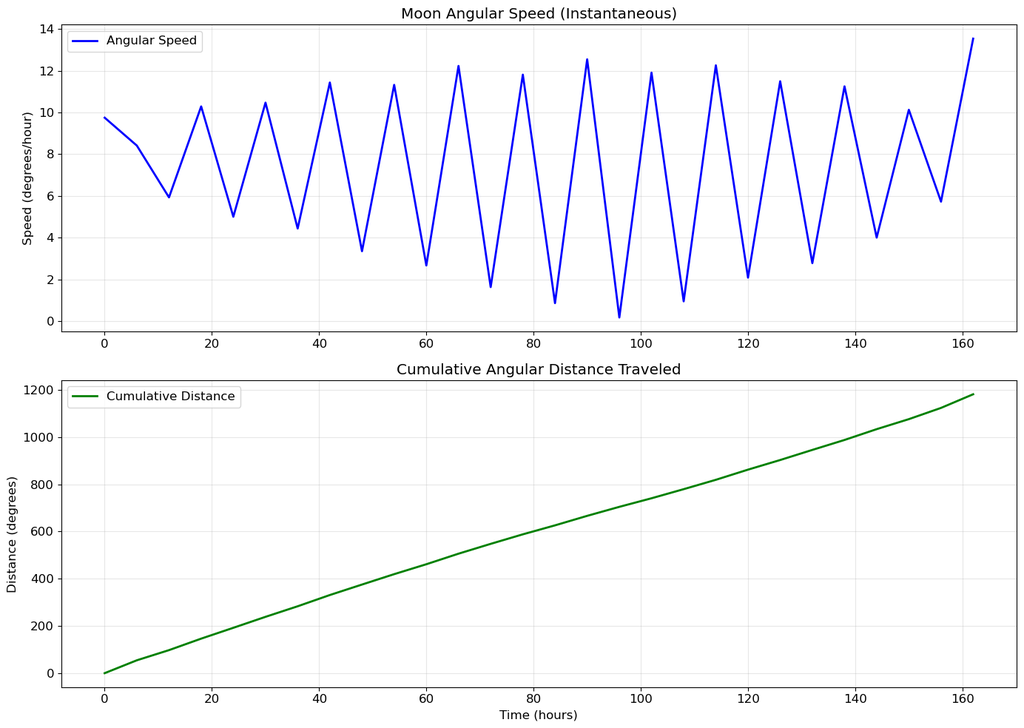

```python
# Create a two-panel visualization showing speed and cumulative distance
fig, (ax1, ax2) = plt.subplots(2, 1, figsize=(14, 10))

# Top panel: Instantaneous angular speed (the function we're integrating)
ax1.plot(time_hours, angular_speed, 'b-', linewidth=2, label='Angular Speed')
ax1.set_ylabel('Speed (degrees/hour)')
ax1.set_title('Moon Angular Speed (Instantaneous)')
ax1.legend()
ax1.grid(True, alpha=0.3)

# Bottom panel: Cumulative distance (the integral of speed)
# This shows the running total of distance traveled up to each time
ax2.plot(time_hours, cumulative_distance, 'g-', linewidth=2, label='Cumulative Distance')
ax2.set_xlabel('Time (hours)')
ax2.set_ylabel('Distance (degrees)')
ax2.set_title('Cumulative Angular Distance Traveled')
ax2.legend()
ax2.grid(True, alpha=0.3)

plt.tight_layout()
plt.show()
```

The cumulative plot shows steady, monotonic growth - the curve always increases because we're integrating speed (always positive). The Moon continuously accumulates angular distance. Flat regions would indicate periods when the Moon was stationary (which never happens), while steep regions indicate rapid motion. The changing slope of the cumulative curve directly reflects the instantaneous speed shown in the top panel - this is the fundamental theorem of calculus in action!

Let's create one more visualization showing how integration connects to the area under the curve. We'll show both the speed curve and shade regions to illustrate partial integrals:

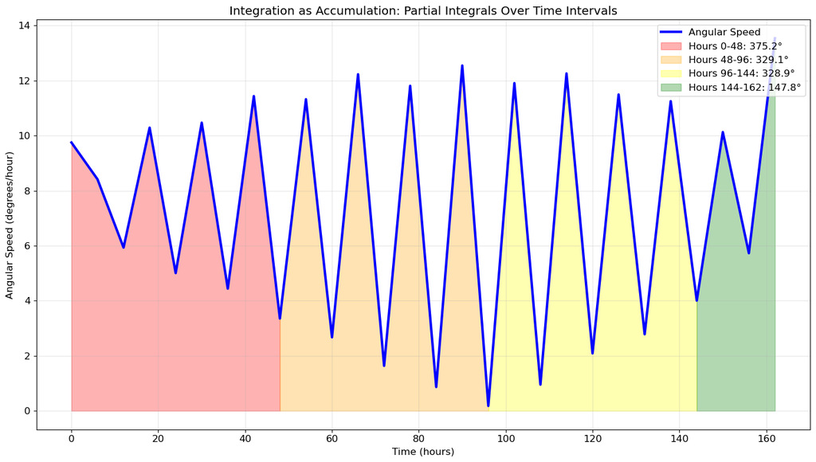

```
Total distance: 1181.00° (sum of all colored areas)
```

```python
# Create a visualization showing how integration accumulates over time intervals
fig, ax = plt.subplots(figsize=(14, 8))

# Plot the speed curve
ax.plot(time_hours, angular_speed, 'b-', linewidth=3, label='Angular Speed', zorder=3)

# Divide the time period into four sections and color each differently
time_sections = [0, 48, 96, 144, time_hours[-1]]  # Time boundaries in hours
colors = ['red', 'orange', 'yellow', 'green']

# For each time section, fill the area under the curve and compute partial integral
for i in range(len(time_sections)-1):

    # Create mask for this time interval
    mask = (time_hours >= time_sections[i]) & (time_hours <= time_sections[i+1])

    # Compute the integral over just this interval
    partial_integral = integrate.trapezoid(angular_speed[mask], time_hours[mask])

    # Fill the area with color and add to legend
    ax.fill_between(time_hours[mask], 0, angular_speed[mask],
                    alpha=0.3, color=colors[i],
                    label=f'Hours {time_sections[i]:.0f}-{time_sections[i+1]:.0f}: {partial_integral:.1f}°')

# Labels and formatting
ax.set_xlabel('Time (hours)')
ax.set_ylabel('Angular Speed (degrees/hour)')
ax.set_title('Integration as Accumulation: Partial Integrals Over Time Intervals')
ax.legend(loc='upper right')
ax.grid(True, alpha=0.3)

plt.tight_layout()
plt.show()

# Verify that partial integrals sum to total
print(f"\nTotal distance: {total_distance_trapz:.2f}° (sum of all colored areas)")
```

This visualization shows how integration accumulates contributions from different time intervals. Each colored region represents the angular distance traveled during that time period. The total distance is the sum of all these colored areas. This makes the geometric meaning of integration concrete - it's literally the area under the curve.

Unlike differentiation, integration is numerically stable - noise gets averaged out rather than amplified, which is why integration is much more forgiving of measurement errors. More data points generally give better accuracy, but the returns diminish. For method choice, Simpson's rule beats trapezoidal for smooth functions, but both work well for most practical problems. Cumulative integration shows how quantities build up over time and is extremely useful for visualization and understanding accumulation processes.

## Summary

### Key Concepts

In this lecture, you've learned:

- **Interpolation Methods**: Why linear interpolation connects points with straight lines (simple but creates kinks at data points), how cubic splines create smooth curves with continuous derivatives (better for smooth astronomical functions), understanding 2D interpolation with `RectBivariateSpline` for functions of multiple variables like altitude grids, and why denser sampling grids reveal interpolation quality
- **Angular Coordinate Handling**: Always unwrapping angular coordinates (RA, azimuth, phase) before interpolating using `np.unwrap(angles, period=360.0)` for degree data to detect jumps larger than 180° and make sequences continuous, interpolating the unwrapped values, then wrapping results back to [0°, 360°) using modulo to avoid catastrophic failures at wrap points
- **Numerical Differentiation**: Computing derivatives using SciPy's spline-based methods through `scipy.interpolate.CubicSpline` objects with derivative evaluation, understanding that both methods fit smooth splines then compute derivatives analytically (more robust than finite differences), evaluating derivatives at any point on the spline, and finding extrema by locating where derivatives equal zero
- **Peak Finding**: Using `scipy.signal.find_peaks()` to automatically identify local maxima in data with customizable criteria (prominence, height, distance between peaks), understanding peak properties like prominence (how much a peak stands out from surroundings) and width, applying peak finding to locate astronomical events like maximum altitude or brightness variations
- **Numerical Integration**: Using trapezoidal rule `scipy.integrate.trapezoid(y, x)` to approximate area with trapezoids (simple and reliable), applying Simpson's rule `simpson(y, x)` with parabolas for better accuracy on smooth functions, tracking running totals with cumulative integration `cumulative_trapezoid()`, understanding that integration is numerically stable and averages out noise

### What You Can Now Do

After working through this material, you should be able to:

- Create fast ephemeris lookup tables by interpolating sparse SkyField computations to arbitrary times
- Choose appropriate interpolation methods based on accuracy requirements and data characteristics
- Handle angular coordinates correctly by unwrapping before interpolation
- Compute accumulated quantities like total angular distances using numerical integration
- Calculate rates of change from position data using spline-based differentiation
- Use derivatives to identify extrema and find precise timing of astronomical events
- Create 2D interpolation grids for quantities depending on multiple variables
- Visualize integration geometrically as areas under curves

### Practice Suggestions

To solidify these concepts:

1. Create an hourly Moon ephemeris table and interpolate to minute precision
2. Compute the total angular distance the Moon travels over one complete lunation
3. Find what fraction of nights Jupiter is above 30° altitude from your location
4. Compute the Moon's angular velocity and acceleration throughout a week
5. Create a 2D interpolator for the Moon's altitude as a function of time and latitude
6. Calculate when the Moon reaches maximum altitude each day over a month
7. Integrate different quantities and visualize cumulative results

### Looking Ahead

You now have powerful tools for working with discrete astronomical data - interpolating between computed points, integrating to find accumulations, and differentiating to find rates of change. These techniques complement the ephemeris calculations from Lecture 15, giving you a complete computational toolkit for analyzing celestial motion. In the next lecture, you'll learn statistical analysis methods using the `scipy.stats` module, including working with probability distributions, random sampling, computing descriptive statistics, performing chi-squared tests, and calculating confidence intervals for your astronomical data.